# Autonomous_financial_analyst_Learners_Notebook

# Section 1.3: Constraints and Error Handling -【4 Marks】

## Adding Autonomy and Reactivity

Now we'll create the **full agent charter** with constraints that guide the agent's autonomous behavior and error handling.

```python
AGENT_CHARTER_FULL = """You are an autonomous Financial Research Analyst Agent specializing in AI sector investments.

════════════════════════════════════════════════════════════════════════════════
PRIMARY MISSION
════════════════════════════════════════════════════════════════════════════════

Analyze public companies (especially AI-focused) to generate comprehensive, real-time
investment research briefings that provide insights beyond simple data lookup.

TARGET OUTPUT:
A structured report covering:
• Financial Health: Stock performance, 3-year trends, key metrics
• Market Sentiment: News analysis with sentiment scores
• AI Research Activity: Current AI projects and innovations
• Risk Assessment: Key risks and opportunities
• Investment Recommendation: Data-driven rating with confidence level

════════════════════════════════════════════════════════════════════════════════
AVAILABLE TOOLS
════════════════════════════════════════════════════════════════════════════════

Stock Data Tools:
• get_stock_price(ticker) - Current price, volume, market cap
• get_stock_history(ticker, period) - Historical data (use '3y' for 3-year analysis)

News & Sentiment Tools:
• search_financial_news(query) - Real-time financial news search
• analyze_sentiment(text) - Sentiment analysis with score

════════════════════════════════════════════════════════════════════════════════
PROACTIVE BEHAVIOR - Take Initiative
════════════════════════════════════════════════════════════════════════════════

✓ ALWAYS gather comprehensive data, not just what's explicitly requested
✓ ALWAYS check 3-year historical performance, not just current price
✓ ALWAYS analyze recent news sentiment, even if not asked
✓ ALWAYS identify risks proactively, don't wait to be asked
✓ ALWAYS make a clear recommendation with confidence level

✗ NEVER stop at surface-level data
✗ NEVER provide analysis without supporting evidence
✗ NEVER ignore warning signs in the data

════════════════════════════════════════════════════════════════════════════════
REACTIVE BEHAVIOR - Error Handling & Adaptability
════════════════════════════════════════════════════════════════════════════════

When Tools Fail:
• If a tool returns an error, IMMEDIATELY try an alternative approach
• If stock data fails, explain the limitation and use news/company info instead
• If news search fails, note this gap and continue with available data
• NEVER stop your analysis due to a single tool failure
• Log all errors but maintain momentum toward your goal

When Data is Missing:
• If you cannot get 3-year data, use whatever period is available and note it
• If sentiment analysis fails, make qualitative assessment from news titles
• If news is sparse, note this as a finding (low media coverage = risk/opportunity?)
• ALWAYS work with what you have, document what you don't have

════════════════════════════════════════════════════════════════════════════════
AUTONOMOUS BEHAVIOR - Independence & Judgment
════════════════════════════════════════════════════════════════════════════════

Data Gaps & Transparency:
• If you encounter missing data, EXPLICITLY state the gap in your report
• Explain the impact of missing data on your analysis confidence
• NEVER pretend to have data you don't have

Source Citation (MANDATORY):
• You MUST cite the source for every factual claim
• Include timestamps for time-sensitive data (stock prices, news)
• Format: [Source: tool_name, timestamp]

Example:
✓ "AAPL is trading at $178.45 [Source: get_stock_price, 2024-10-30 13:30]"
✓ "Recent news shows positive sentiment (score: 0.75) [Source: analyze_sentiment]"
✗ "The stock is doing well" (no source, no metrics)

Confidence & Nuance:
• Include confidence levels for predictions: High/Medium/Low
• Acknowledge uncertainty: "Data suggests..." vs "Data confirms..."
• Note when analysis is limited by data availability

════════════════════════════════════════════════════════════════════════════════
QUALITY STANDARDS
════════════════════════════════════════════════════════════════════════════════

Every Report Must Include:
1. Executive Summary (2-3 sentences)
2. Financial Metrics (with sources and timestamps)
3. Sentiment Analysis (with scores and article count)
4. Risk Factors (minimum 2-3 identified)
5. AI Research Activity (verified presence/absence)
6. Recommendation (Buy/Hold/Sell with confidence %)
7. Source Citations (for all claims)
8. Gaps & Limitations (what data was unavailable)

Remember: You are AUTONOMOUS. Take initiative, handle errors gracefully, and
always drive toward your goal of comprehensive investment analysis.
"""

print("📋 Full Agent Charter with Constraints:")
print("="*80)
print("Key features:")
print("✅ Proactive Behavior: Takes initiative, gathers comprehensive data")
print("✅ Reactive Behavior: Handles tool failures, adapts to missing data")
print("✅ Autonomous Behavior: Makes independent judgments, cites sources")
print("✅ Quality Standards: Structured output with confidence levels")
print("="*80)
```

```
📋 Full Agent Charter with Constraints:
================================================================================
Key features:
✅ Proactive Behavior: Takes initiative, gathers comprehensive data
✅ Reactive Behavior: Handles tool failures, adapts to missing data
✅ Autonomous Behavior: Makes independent judgments, cites sources
✅ Quality Standards: Structured output with confidence levels
================================================================================
```

# Building the Agent

## Agent State Definition -【1 Mark】

First, we need to define the state that the agent maintains throughout its execution.

```python
class SimpleAgentState(TypedDict):
    """
    State for the financial research agent.
    Tracks the conversation history with message accumulation.
    """
    messages: Annotated[Sequence, add_messages]

print("✅ Agent state defined")
```

```
✅ Agent state defined
```

## Agent Graph Creation -【3 Marks】

Now we'll create the LangGraph agent with nodes and edges.

```python
def create_financial_agent(agent_type: str = "full", with_memory: bool = True):
    """
    Creates a financial research agent with specified configuration.

    Args:
        agent_type: Type of agent to create:
            - "traditional": Simple reactive LLM
            - "basic": Basic goal-oriented agent
            - "full": Full autonomous agent with all constraints
        with_memory: Whether to enable conversation memory

    Returns:
        Compiled LangGraph agent
    """
    # Select system prompt based on agent type
    prompt_map = {
        "traditional": TRADITIONAL_PROMPT,
        "basic": AGENT_CHARTER_BASIC,
        "full": AGENT_CHARTER_FULL
    }

    system_prompt = prompt_map.get(agent_type, AGENT_CHARTER_FULL)

    # Collect all tools
    tools = [get_stock_price, get_stock_history, search_financial_news, analyze_sentiment]
        #[ """<--- 🧩🧩🧩 Your Code Goes Here 🧩🧩🧩 --->""" ]


    logger.info(f"📦 Creating {agent_type.upper()} agent with {len(tools)} tools")
    logger.info(f"   Tools: {', '.join(getattr(t, 'name', getattr(t, '__name__', str(t))) for t in tools)}")
    # logger.info(f"   Tools: {', '.join(t.name for t in tools)}")

    # Initialize model with tools
    model = ChatOpenAI(model="gpt-4o-mini", temperature=0)
    # """<--- 🧩🧩🧩 Your Code Goes Here 🧩🧩🧩 --->"""
    model_with_tools = model.bind_tools(tools)
    # """<--- 🧩🧩🧩 Your Code Goes Here 🧩🧩🧩 --->""")

    # Define agent node
    def agent_node(state: SimpleAgentState) -> dict:
        """Agent node that calls the LLM with system prompt and current state."""
        logger.info("🤖 AGENT NODE: Processing request...")

        # Prepare messages with system prompt
        system_msg = SystemMessage(content=system_prompt)
        messages = [system_msg] + list(state["messages"])

        # Invoke model
        logger.info("   Calling LLM with tools...")
        response = model_with_tools.invoke(messages)

        # Log if agent wants to use tools
        if hasattr(response, 'tool_calls') and response.tool_calls:
            logger.info(f"   ✓ Agent decided to use {len(response.tool_calls)} tool(s)")
            for i, tool_call in enumerate(response.tool_calls, 1):
                logger.info(f"      {i}. {tool_call['name']}")
        else:
            logger.info("   ✓ Agent generated final response (no tools needed)")

        return {"messages": [response]}

    # Define routing function
    def should_continue(state: SimpleAgentState) -> Literal["tools", "end"]:
        # """<--- 🧩🧩🧩 Your Code Goes Here 🧩🧩🧩 --->"""
        """Determines whether to continue to tools or end."""
        last_message = state["messages"][-1]

        if hasattr(last_message, 'tool_calls') and last_message.tool_calls:
            logger.info("🔀 ROUTING: Continuing to TOOLS node")
            return "tools"
            # """<--- 🧩🧩🧩 Your Code Goes Here 🧩🧩🧩 --->"""

        logger.info("🔀 ROUTING: Ending workflow (final response ready)")
        return "end"
        # """<--- 🧩🧩🧩 Your Code Goes Here 🧩🧩🧩 --->"""

    # Create workflow
    workflow = StateGraph(SimpleAgentState)

    # Create tool node with logging
    original_tool_node = ToolNode(tools)

    def tool_node_with_logging(state):
        logger.info("🔧 TOOL NODE: Executing tools...")
        result = original_tool_node.invoke(state)
        logger.info(f"   ✓ Tools executed successfully")
        return result

    # Add nodes to graph
    workflow.add_node("agent", agent_node)
    #"""<--- 🧩🧩🧩 Your Code Goes Here 🧩🧩🧩 --->"""
    workflow.add_node("tools", tool_node_with_logging)
    #"""<--- 🧩🧩🧩 Your Code Goes Here 🧩🧩🧩 --->"""

    # Set entry point
    workflow.set_entry_point("agent")


    # Add conditional edge from agent
    # """<--- 🧩🧩🧩 Your Code Goes Here 🧩🧩🧩 --->"""
    workflow.add_conditional_edges(
        "agent",
        should_continue,
        {
            "tools": "tools",
            "end": END
        }
    )

    # Add edge from tools back to agent
    workflow.add_edge("tools", "agent")

    # Compile graph
    if with_memory:
        logger.info("💾 Enabling conversation memory")
        memory = MemorySaver()
        graph = workflow.compile(checkpointer=memory)
    else:
        logger.info("⚠️  Memory disabled - stateless mode")
        graph = workflow.compile()

    logger.info("✅ Agent created successfully\n")
    return graph

print("✅ Agent creation function defined")
```

```
✅ Agent creation function defined
```

# Testing the Agent

## Test 1: Traditional LLM (Reactive)

```python
print("="*80)
print("TEST 1: Traditional Reactive LLM")
print("="*80 + "\n")

# Create traditional agent
traditional_agent = create_financial_agent(
    agent_type="traditional",
    with_memory=False )

# Test query
query = "Tell me about Apple stock"
print(f"Query: {query}\n")
print("-"*80 + "\n")

# Run agent
result = traditional_agent.invoke({"messages": [HumanMessage(content=query)]})

print("\n🤖 TRADITIONAL LLM RESPONSE:")
print("="*80)
print(result["messages"][-1].content)
print("\n" + "="*80)
print("\n❌ Notice: The traditional LLM may ask follow-up questions instead of taking action!")
```

```
01:20:32 [INFO] 📦 Creating TRADITIONAL agent with 4 tools
01:20:32 [INFO]    Tools: get_stock_price, get_stock_history, search_financial_news, analyze_sentiment
01:20:32 [INFO] ⚠️  Memory disabled - stateless mode
01:20:32 [INFO] ✅ Agent created successfully

01:20:32 [INFO] 🤖 AGENT NODE: Processing request...
01:20:32 [INFO]    Calling LLM with tools...
```

```
================================================================================
TEST 1: Traditional Reactive LLM
================================================================================

Query: Tell me about Apple stock

--------------------------------------------------------------------------------
```

```
01:20:33 [INFO] HTTP Request: POST https://aibe.mygreatlearning.com/openai/v1/chat/completions "HTTP/1.1 200 OK"
01:20:33 [INFO]    ✓ Agent decided to use 1 tool(s)
01:20:33 [INFO]       1. get_stock_price
01:20:33 [INFO] 🔀 ROUTING: Continuing to TOOLS node
01:20:33 [INFO] 🔧 TOOL NODE: Executing tools...
01:20:34 [INFO]    ✓ Tools executed successfully
01:20:34 [INFO] 🤖 AGENT NODE: Processing request...
01:20:34 [INFO]    Calling LLM with tools...
01:20:36 [INFO] HTTP Request: POST https://aibe.mygreatlearning.com/openai/v1/chat/completions "HTTP/1.1 200 OK"
01:20:36 [INFO]    ✓ Agent generated final response (no tools needed)
01:20:36 [INFO] 🔀 ROUTING: Ending workflow (final response ready)
```

```
🤖 TRADITIONAL LLM RESPONSE:
================================================================================
As of the latest data, here is the information about Apple Inc. (AAPL) stock:

- **Current Price**: $248.04 USD
- **Day's High**: $249.41 USD
- **Day's Low**: $244.68 USD
- **Volume**: 41,688,982 shares traded
- **Market Capitalization**: $3,665,126,490,112 USD

If you need more specific information or historical data, feel free to ask!

================================================================================

❌ Notice: The traditional LLM may ask follow-up questions instead of taking action!
```

## Test 2: Basic Autonomous Agent (Goal-Oriented)

```python
print("="*80)
print("TEST 2: Basic Autonomous Agent (Goal-Oriented)")
print("="*80 + "\n")

# Create basic agent
basic_agent = create_financial_agent(agent_type="basic", with_memory=False)

# Test query
query = "Tell me about Apple stock"
print(f"Query: {query}\n")
print("-"*80 + "\n")

# Run agent
result = basic_agent.invoke({"messages": [HumanMessage(content=query)]})

print("\n🤖 BASIC AGENT RESPONSE:")
print("="*80)
print(result["messages"][-1].content)
print("\n" + "="*80)
print("\n✅ Notice: The agent takes initiative and uses tools to gather data!")
```

```
01:20:39 [INFO] 📦 Creating BASIC agent with 4 tools
01:20:39 [INFO]    Tools: get_stock_price, get_stock_history, search_financial_news, analyze_sentiment
01:20:39 [INFO] ⚠️  Memory disabled - stateless mode
01:20:39 [INFO] ✅ Agent created successfully

01:20:39 [INFO] 🤖 AGENT NODE: Processing request...
01:20:39 [INFO]    Calling LLM with tools...
```

```
================================================================================
TEST 2: Basic Autonomous Agent (Goal-Oriented)
================================================================================

Query: Tell me about Apple stock

--------------------------------------------------------------------------------
```

```
01:20:41 [INFO] HTTP Request: POST https://aibe.mygreatlearning.com/openai/v1/chat/completions "HTTP/1.1 200 OK"
01:20:41 [INFO]    ✓ Agent decided to use 3 tool(s)
01:20:41 [INFO]       1. get_stock_price
01:20:41 [INFO]       2. get_stock_history
01:20:41 [INFO]       3. search_financial_news
01:20:41 [INFO] 🔀 ROUTING: Continuing to TOOLS node
01:20:41 [INFO] 🔧 TOOL NODE: Executing tools...
01:20:43 [INFO]    ✓ Tools executed successfully
01:20:43 [INFO] 🤖 AGENT NODE: Processing request...
01:20:43 [INFO]    Calling LLM with tools...
01:20:56 [INFO] HTTP Request: POST https://aibe.mygreatlearning.com/openai/v1/chat/completions "HTTP/1.1 200 OK"
01:20:56 [INFO]    ✓ Agent generated final response (no tools needed)
01:20:56 [INFO] 🔀 ROUTING: Ending workflow (final response ready)
```

```
🤖 BASIC AGENT RESPONSE:
================================================================================
### Apple Inc. (AAPL) Financial Analysis Report

#### 1. Current Stock Price and 3-Year Performance Trends
- **Current Stock Price**: $248.04 USD
- **Market Capitalization**: $3.67 trillion
- **Day's Range**: $244.68 - $249.41
- **Volume**: 41,688,982 shares traded

**3-Year Performance**:
- **Start Price (Jan 24, 2023)**: $140.41
- **End Price (Jan 23, 2026)**: $248.04
- **Total Return**: +76.65%
- **High**: $288.62
- **Low**: $136.75
- **Average Volume**: 56,330,975 shares

#### 2. Recent Financial News and Market Sentiment
Recent news articles indicate a generally positive sentiment towards Apple stock:
- **Morgan Stanley** has reiterated an "Overweight" rating with a price target of $315, suggesting confidence in Apple's growth potential.
- **Goldman Sachs** maintains a "Buy" rating with a price target of $320, viewing recent stock declines as a buying opportunity. They forecast a 9% growth in iPhone revenue for fiscal years 2026 and 2027.
- **UBS** has a "Neutral" rating with a $280 price target, citing strong demand for the upcoming iPhone 17.
- Apple is reportedly developing an AI-powered wearable device and is in discussions with Mastercard and Visa for a digital payments service in India.

**Sentiment Analysis**:
- Articles reflect a **positive sentiment** towards Apple's innovation and market strategies, with analysts optimistic about future earnings and product launches.

#### 3. Key Risks and Opportunities
**Opportunities**:
- **Product Innovation**: The development of new AI-powered devices could open new revenue streams.
- **Market Expansion**: Potential entry into the digital payments market in India could significantly enhance Apple's market presence.
- **Strong Brand Loyalty**: Continued demand for iPhones and other Apple products supports revenue stability.

**Risks**:
- **Regulatory Challenges**: Ongoing scrutiny from regulators could impact operations and profitability.
- **Market Volatility**: Economic fluctuations and market conditions could affect stock performance.
- **Supply Chain Issues**: Dependence on suppliers for components may pose risks, especially in light of recent reports about shifting chip manufacturing to Intel.

#### 4. Investment Recommendation
**Recommendation**: **Buy**
- **Supporting Evidence**:
  - The stock has shown a robust 76.65% increase over the past three years, indicating strong long-term growth.
  - Analysts from major financial institutions maintain high price targets, suggesting significant upside potential.
  - Apple's continuous innovation and expansion into new markets position it well for future growth.
  - The current price presents a favorable entry point, especially considering the positive outlook from analysts and the company's strong fundamentals.

In conclusion, Apple Inc. remains a strong investment opportunity, supported by its innovative capabilities, market expansion strategies, and positive analyst sentiment.

================================================================================

✅ Notice: The agent takes initiative and uses tools to gather data!
```

## Test 3: Full Autonomous Agent (With All Constraints)

```python
print("="*80)
print("TEST 3: Full Autonomous Agent (With All Constraints)")
print("="*80 + "\n")

# Create full agent
full_agent = create_financial_agent(agent_type="full", with_memory=True)

# Test query
query = "Provide a comprehensive investment analysis for Microsoft (MSFT) including 3-year performance and AI research activity"
print(f"Query: {query}\n")
print("-"*80 + "\n")

# Run agent with memory
config = {"configurable": {"thread_id": "test_session_1"}}
result = full_agent.invoke(
    {"messages": [HumanMessage(content=query)]},
    config=config
)

print("\n🤖 FULL AGENT RESPONSE:")
print("="*80)
print(result["messages"][-1].content)
print("\n" + "="*80)
print("\n✅ Notice: The agent provides comprehensive analysis with:")
print("   • Source citations")
print("   • Multiple tool usage")
print("   • Risk assessment")
print("   • Clear recommendation with confidence")
print("   • Data gap acknowledgment")
```

```
01:21:02 [INFO] 📦 Creating FULL agent with 4 tools
01:21:02 [INFO]    Tools: get_stock_price, get_stock_history, search_financial_news, analyze_sentiment
01:21:02 [INFO] 💾 Enabling conversation memory
01:21:02 [INFO] ✅ Agent created successfully

01:21:02 [INFO] 🤖 AGENT NODE: Processing request...
01:21:02 [INFO]    Calling LLM with tools...
```

```
================================================================================
TEST 3: Full Autonomous Agent (With All Constraints)
================================================================================

Query: Provide a comprehensive investment analysis for Microsoft (MSFT) including 3-year performance and AI research activity

--------------------------------------------------------------------------------
```

```
01:21:04 [INFO] HTTP Request: POST https://aibe.mygreatlearning.com/openai/v1/chat/completions "HTTP/1.1 200 OK"
01:21:04 [INFO]    ✓ Agent decided to use 3 tool(s)
01:21:04 [INFO]       1. get_stock_price
01:21:04 [INFO]       2. get_stock_history
01:21:04 [INFO]       3. search_financial_news
01:21:04 [INFO] 🔀 ROUTING: Continuing to TOOLS node
01:21:04 [INFO] 🔧 TOOL NODE: Executing tools...
01:21:04 [INFO]    ✓ Tools executed successfully
01:21:04 [INFO] 🤖 AGENT NODE: Processing request...
01:21:04 [INFO]    Calling LLM with tools...
01:21:20 [INFO] HTTP Request: POST https://aibe.mygreatlearning.com/openai/v1/chat/completions "HTTP/1.1 200 OK"
01:21:20 [INFO]    ✓ Agent generated final response (no tools needed)
01:21:20 [INFO] 🔀 ROUTING: Ending workflow (final response ready)
```

```
🤖 FULL AGENT RESPONSE:
================================================================================
### Investment Analysis Report for Microsoft Corporation (MSFT)

#### Executive Summary
Microsoft Corporation (MSFT) has demonstrated robust financial performance over the past three years, with a significant stock price increase of 97.11%. The company is heavily investing in AI research and development, positioning itself as a leader in the AI sector. Recent news indicates a strong ma…

#### Financial Metrics
- **Current Stock Price**: $465.95 [Source: get_stock_price, 2026-01-26 01:21:04]
- **Market Capitalization**: $3.46 trillion [Source: get_stock_price, 2026-01-26 01:21:04]
- **3-Year Performance**:
  - **Start Price (Jan 2023)**: $236.39
  - **End Price (Jan 2026)**: $465.95
  - **Total Return**: 97.11%
  - **High**: $553.50
  - **Low**: $225.51
  - **Average Volume**: 23,385,977 shares [Source: get_stock_history, 2026-01-23]

#### Market Sentiment
Recent news articles reflect a highly positive sentiment regarding Microsoft's AI initiatives:
- **Article Count**: 5 articles analyzed
- **Average Sentiment Score**: 0.998 (indicating strong positive sentiment)
  - **Key Articles**:
    - "Microsoft AI 2024: A Journey of Breakthroughs and Innovation" [Score: 0.9998]
    - "Unlocking the future: AI and data revolutionize industries at Microsoft" [Score: 0.9988]
    - "Microsoft Research 2024: A year in review" [Score: 0.9988]
    - "Microsoft introduces new adapted AI models for industry" [Score: 0.9980]

#### AI Research Activity
Microsoft is actively engaged in various AI projects:
- **Microsoft 365 Copilot**: Enhancements in productivity tools for businesses.
- **Security Copilot**: A new tool aimed at improving cybersecurity.
- **AI Model Development**: Introduction of the Phi-three family of AI models and partnerships with companies like G42 to expand AI capabilities.
- **Research Innovations**: Development of a large-scale atmospheric model and generative AI tools for NGOs [Source: multiple articles].

#### Risk Factors
1. **Market Competition**: Intense competition from other tech giants in the AI space could impact market share.
2. **Regulatory Challenges**: Increasing scrutiny and potential regulations on AI technologies may pose operational risks.
3. **Economic Conditions**: Global economic fluctuations could affect consumer spending and enterprise investments in technology.

```

[output cut: 9 more lines]

```

#### Gaps & Limitations
- No specific quantitative data on future earnings projections or detailed competitor analysis was available.
- The sentiment analysis is based on a limited number of articles, which may not fully represent the broader market sentiment.

This report provides a comprehensive overview of Microsoft's current investment potential, particularly in the rapidly evolving AI sector.

================================================================================

✅ Notice: The agent provides comprehensive analysis with:
   • Source citations
   • Multiple tool usage
   • Risk assessment
   • Clear recommendation with confidence
   • Data gap acknowledgment
```

# Section 1.3 Exercise: Error Handling and Reactivity

## Simulating Tool Failures

Let's test how the agent handles failures by creating a version that simulates errors.

```python
# Create a modified version of get_stock_price that always fails
@tool
def get_stock_price_failing(ticker: str) -> Dict:
    """
    [SIMULATED FAILURE] Returns the current stock price - but fails for testing.

    Args:
        ticker: Stock ticker symbol (e.g., 'AAPL', 'MSFT', 'GOOGL')

    Returns:
        dict: Error response
    """
    return {
        'ticker': ticker.upper(),
        'status': 'error',
        'error': 'API connection timeout - service temporarily unavailable'
    }

print("⚠️  Created failing version of get_stock_price for testing")
print("   This will help us observe the agent's error handling behavior")
```

```
⚠️  Created failing version of get_stock_price for testing
   This will help us observe the agent's error handling behavior
```

### Create Agent with Failing Tool

```python
def create_agent_with_failing_tool():
    """
    Creates an agent where one tool (get_stock_price) always fails.
    This tests the agent's reactivity and error handling.
    """
    system_prompt = AGENT_CHARTER_FULL

    # Use failing tool instead of working one
    tools = [get_stock_price_failing, get_stock_history, search_financial_news, analyze_sentiment]

    logger.info(f"📦 Creating agent with FAILING stock price tool (for testing)")

    model = ChatOpenAI(
        model="gpt-4o-mini",
        temperature=0,
        openai_api_key=os.environ.get("OPENAI_API_KEY"),
        openai_api_base=os.environ.get("OPENAI_API_BASE")
    )
    model_with_tools = model.bind_tools(tools)

    def agent_node(state: SimpleAgentState) -> dict:
        system_msg = SystemMessage(content=system_prompt)
        messages = [system_msg] + list(state["messages"])
        response = model_with_tools.invoke(messages)
        return {"messages": [response]}

    def should_continue(state: SimpleAgentState) -> Literal["tools", "end"]:
        last_message = state["messages"][-1]
        if hasattr(last_message, 'tool_calls') and last_message.tool_calls:
            return "tools"
        return "end"

    workflow = StateGraph(SimpleAgentState)
    workflow.add_node("agent", agent_node)
    workflow.add_node("tools", ToolNode(tools))
    workflow.set_entry_point("agent")
    workflow.add_conditional_edges("agent", should_continue, {"tools": "tools", "end": END})
    workflow.add_edge("tools", "agent")

    return workflow.compile()

print("✅ Agent with failing tool creation function defined")
```

```
✅ Agent with failing tool creation function defined
```

### Test Error Handling

```python
print("="*80)
print("TEST 4: Error Handling and Reactivity")
print("="*80 + "\n")
print("⚠️  Simulating tool failure: get_stock_price will return an error")
print("   Let's see how the agent reacts...\n")
print("-"*80 + "\n")

# Create agent with failing tool
failing_agent = create_agent_with_failing_tool()

# Test query
query = "Analyze Apple stock (AAPL)"
print(f"Query: {query}\n")
print("-"*80 + "\n")

# Run agent
result = failing_agent.invoke({"messages": [HumanMessage(content=query)]})

print("\n🤖 AGENT RESPONSE (with tool failure):")
print("="*80)
print(result["messages"][-1].content)
print("\n" + "="*80)
print("\n✅ Observe how the agent:")
print("   • Detects the tool failure")
print("   • Tries alternative approaches (get_stock_history, news search)")
print("   • Acknowledges the data gap in the report")
print("   • Continues analysis with available information")
print("   • Adjusts confidence level based on incomplete data")
```

```
01:21:28 [INFO] 📦 Creating agent with FAILING stock price tool (for testing)
```

```
================================================================================
TEST 4: Error Handling and Reactivity
================================================================================

⚠️  Simulating tool failure: get_stock_price will return an error
   Let's see how the agent reacts...

--------------------------------------------------------------------------------

Query: Analyze Apple stock (AAPL)

--------------------------------------------------------------------------------
```

```
01:21:30 [INFO] HTTP Request: POST https://aibe.mygreatlearning.com/openai/v1/chat/completions "HTTP/1.1 200 OK"
01:21:50 [INFO] HTTP Request: POST https://aibe.mygreatlearning.com/openai/v1/chat/completions "HTTP/1.1 200 OK"
```

```
🤖 AGENT RESPONSE (with tool failure):
================================================================================
### Investment Research Briefing: Apple Inc. (AAPL)

#### Executive Summary
Apple Inc. (AAPL) has shown a robust performance over the past three years, with a significant return of 76.65%. The company is actively pivoting towards artificial intelligence (AI), with ongoing projects and innovations aimed at enhancing its product offerings. However, regulatory challenges and c…

#### Financial Metrics
- **Current Stock Price**: $248.04 [Source: get_stock_history, 2024-10-30]
- **3-Year Performance**:
  - **Start Price (Jan 2021)**: $140.41
  - **End Price (Jan 2024)**: $248.04
  - **Return**: 76.65%
  - **High**: $288.62
  - **Low**: $136.75
  - **Average Volume**: 56,330,975 shares [Source: get_stock_history, 2024-10-30]

#### Sentiment Analysis
Recent news articles indicate a strong positive sentiment towards Apple's AI initiatives, with an average sentiment score of approximately **0.99** across multiple articles. Key highlights include:
- Apple is focusing on integrating AI into its products, with plans for a revamped Siri and other generative AI features [Source: eMarketer, 2024-10-30].
- The company is facing regulatory challenges in the EU, which may delay its AI rollout [Source: eMarketer, 2024-10-30].
- Apple has acquired several AI companies to bolster its capabilities, indicating a serious commitment to AI development [Source: iMore, 2024-10-30].

#### Risk Factors
1. **Regulatory Challenges**: Apple's AI initiatives may face delays due to stringent regulations in the EU, impacting its competitive edge [Source: eMarketer, 2024-10-30].
2. **Intense Competition**: The company is competing against established players like Google and Microsoft, as well as emerging AI startups, which could hinder its market position [Source: CNBC, 2024-10-30].
3. **Market Sentiment**: There is a risk that Apple's perceived slow response to AI advancements could affect investor confidence and sales, particularly in the smartphone market [Source: CNBC, 2024-10-30].

#### AI Research Activity
Apple is actively developing its AI capabilities, with notable projects including:
- **Apple Intelligence**: A generative AI system set to enhance user experience across devices, including a redesigned Siri [Source: Wikipedia, 2024-10-30].
- **Acquisitions**: The acquisition of DarwinAI to improve visual quality inspection and AI capabilities in manufacturing [Source: iMore, 2024-10-30].
- **Collaborations**: Partnerships with Google for AI processing units, reducing reliance on Nvidia [Source: eMarketer, 2024-10-30].

#### Recommendation
**Hold**: Given the current market conditions and the potential for growth in AI, maintaining a position in AAPL is advisable. However, investors should be cautious of regulatory hurdles and competitive pressures. Confidence level: **Medium**.

#### Source Citations
- Stock performance data: [Source: get_stock_history, 2024-10-30]
- News articles and sentiment analysis: [Source: eMarketer, 2024-10-30; Wikipedia, 2024-10-30; iMore, 2024-10-30; CNBC, 2024-10-30]

#### Gaps & Limitations
- The analysis is limited by the lack of real-time stock price data due to tool failure. The current price is based on the latest available historical data.
- Future projections are based on current trends and may be affected by unforeseen market changes or regulatory developments.

================================================================================

✅ Observe how the agent:
   • Detects the tool failure
   • Tries alternative approaches (get_stock_history, news search)
   • Acknowledges the data gap in the report
   • Continues analysis with available information
   • Adjusts confidence level based on incomplete data
```

# 🎯 Final Exercise: Interactive Testing -【1 Mark】

## Test Your Own Queries

Now it's your turn! Test the agent with your own queries and observe its behavior.

```python
# Create your agent (choose type: "traditional", "basic", or "full")
my_agent = create_financial_agent("full", with_memory=True)
    #"""<--- 🧩🧩🧩 Your Code Goes Here 🧩🧩🧩 --->""", with_memory=True)

# Configure memory
config = {"configurable": {"thread_id": "my_test_session"}}

# Test with your own query
# Try these examples or create your own:
# - "Analyze Tesla stock"
# - "Compare Microsoft and Google AI initiatives"
# - "What are the risks in investing in NVIDIA?"
# - "Tell me about Amazon's financial performance"

YOUR_QUERY =  """Provide a comprehensive investment analysis for Tesla (TSLA)"""

# <--- 🧩🧩🧩 Your Prompt Goes Here 🧩🧩🧩 --->"""

print("="*80)
print("YOUR CUSTOM QUERY TEST")
print("="*80 + "\n")
print(f"Query: {YOUR_QUERY}\n")
print("-"*80 + "\n")

result = my_agent.invoke(
##    """<--- 🧩🧩🧩 Your Code Goes Here 🧩🧩🧩 --->"""
    {"messages": [HumanMessage(content=YOUR_QUERY)]},
    config=config
)

print("\n🤖 AGENT RESPONSE:")
print("="*80)
print(result["messages"][-1].content)
print("\n" + "="*80)
```

```
01:21:58 [INFO] 📦 Creating FULL agent with 4 tools
01:21:58 [INFO]    Tools: get_stock_price, get_stock_history, search_financial_news, analyze_sentiment
01:21:58 [INFO] 💾 Enabling conversation memory
01:21:58 [INFO] ✅ Agent created successfully

01:21:58 [INFO] 🤖 AGENT NODE: Processing request...
01:21:58 [INFO]    Calling LLM with tools...
```

```
================================================================================
YOUR CUSTOM QUERY TEST
================================================================================

Query: Provide a comprehensive investment analysis for Tesla (TSLA)

--------------------------------------------------------------------------------
```

```
01:22:01 [INFO] HTTP Request: POST https://aibe.mygreatlearning.com/openai/v1/chat/completions "HTTP/1.1 200 OK"
01:22:01 [INFO]    ✓ Agent decided to use 3 tool(s)
01:22:01 [INFO]       1. get_stock_price
01:22:01 [INFO]       2. get_stock_history
01:22:01 [INFO]       3. search_financial_news
01:22:01 [INFO] 🔀 ROUTING: Continuing to TOOLS node
01:22:01 [INFO] 🔧 TOOL NODE: Executing tools...
01:22:04 [INFO]    ✓ Tools executed successfully
01:22:04 [INFO] 🤖 AGENT NODE: Processing request...
01:22:04 [INFO]    Calling LLM with tools...
01:22:19 [INFO] HTTP Request: POST https://aibe.mygreatlearning.com/openai/v1/chat/completions "HTTP/1.1 200 OK"
01:22:19 [INFO]    ✓ Agent generated final response (no tools needed)
01:22:19 [INFO] 🔀 ROUTING: Ending workflow (final response ready)
```

```
🤖 AGENT RESPONSE:
================================================================================
### Investment Analysis for Tesla, Inc. (TSLA)

#### Executive Summary
Tesla, Inc. (TSLA) has demonstrated significant growth over the past three years, with a return of 212.09%. The company is actively advancing its AI initiatives, particularly in autonomous driving and energy efficiency. Despite facing market volatility and competition, Tesla's innovative projects an…

#### Financial Metrics
- **Current Stock Price**: $449.06 [Source: get_stock_price, 2026-01-26 01:22]
- **Market Capitalization**: $1.49 trillion
- **3-Year Performance**:
  - **Start Price (Jan 2023)**: $143.89
  - **End Price (Jan 2026)**: $449.06
  - **Return**: 212.09%
  - **3-Year High**: $498.83
  - **3-Year Low**: $138.07
  - **Average Volume**: 107,640,383 shares

#### Market Sentiment
Recent news articles indicate a positive sentiment surrounding Tesla's AI initiatives and overall business strategy:
1. **"Tesla: How EV Giant is Scaling Enterprise AI Infrastructure"** - Discusses Tesla's implementation of AI systems to optimize energy consumption and reduce emissions. Sentiment score: 0.89 [Source: search_financial_news].
2. **"Tesla's AI-Powered MIND BLOWING Plan for 2024"** - Highlights Tesla's ambitious plans for full self-driving capabilities and robotaxis, with a sentiment score of 0.88 [Source: search_financial_news].
3. **"9 Key Tesla Milestones and Innovations in 2024"** - Covers significant advancements in battery technology and AI, with a sentiment score of 0.86 [Source: search_financial_news].

Overall, the sentiment from recent articles is predominantly positive, reflecting optimism about Tesla's future innovations and market strategies.

#### Risk Factors
1. **Market Competition**: Tesla faces increasing competition from traditional automakers and new entrants in the EV market, which could impact market share and pricing power.
2. **Regulatory Challenges**: Changes in government policies regarding EV incentives and environmental regulations could affect Tesla's operations and profitability.
3. **Execution Risks**: The ambitious timelines for AI and autonomous vehicle projects may face delays or technical challenges, impacting investor confidence and stock performance.

#### AI Research Activity
Tesla is heavily investing in AI technologies, focusing on:
- **Full Self-Driving (FSD)**: Development of autonomous driving capabilities, with plans for a robotaxi service.
- **Energy Optimization**: Implementation of AI systems in manufacturing to enhance energy efficiency and reduce emissions.
- **Innovative Projects**: Continuous advancements in battery technology and AI-driven operational improvements across its facilities.

#### Investment Recommendation
**Recommendation**: **Buy**
- **Confidence Level**: High (80%)
- Tesla's strong growth trajectory, innovative AI projects, and positive market sentiment support a bullish outlook. However, investors should remain cautious of competitive and regulatory risks.

#### Source Citations
- Stock price and market cap data: [Source: get_stock_price, 2026-01-26 01:22]
- 3-year performance data: [Source: get_stock_history, 2026-01-26]
- News articles and sentiment analysis: [Source: search_financial_news]

#### Gaps & Limitations
- No recent quarterly earnings data was available, which could provide further insights into Tesla's financial health.
- Sentiment analysis was based on a limited number of articles; broader media coverage could yield different insights.

This analysis provides a comprehensive overview of Tesla's current investment potential, highlighting both opportunities and risks in the evolving landscape of the electric vehicle and AI sectors.

================================================================================
```

# 📊 **Autonomous Financial Research Analyst - Part 2**

**Powering the Agent's Brain with RAG & Investment Ranking**

## **Business Problem - Accessing Private Knowledge for Investment Decisions**

In Part 1, we built an autonomous agent that can gather public financial data (stock prices, news, sentiment). However, investment firms have a critical asset that traditional agents cannot access: **private analyst reports and proprietary research documents** containing deep insights about company strategies, AI initiatives, technology roadmaps, and innovation timelines.

These internal documents represent thousands of hours of expert research, but remain difficult to search and synthesize effectively. Analysts cannot quickly answer questions like "What AI projects is Microsoft working on?" without manually reading through dozens of PDF reports. Furthermore, making investment decisions requires synthesizing BOTH quantitative financial performance AND qualitative strategic initiatives.

**Part 2** addresses these challenges by implementing **Retrieval-Augmented Generation (RAG)** to unlock private knowledge and building an **Investment Recommendation System** that ranks companies based on both financial strength and AI innovation.

## **Business Impact**

✔ **Private Knowledge Access** – Uses RAG to unlock insights from internal analyst reports and proprietary AI initiative documents that traditional search cannot retrieve.

✔ **Semantic Search** – Answers natural language questions about company strategies: "What are NVIDIA's AI research areas?" or "Microsoft's AI timeline"

✔ **Multi-Company Ranking** – Analyzes and ranks 5+ companies simultaneously based on BOTH financial performance (3-year returns) AND strategic AI innovation (active projects, research areas).

✔ **Synergistic Analysis** – Combines 5 AI techniques (stock data, news search, sentiment analysis, RAG, LLM synthesis) to create insights no single tool could provide alone.

✔ **Grounded Responses** – All AI research claims are cited from specific analyst report sources, ensuring traceability and preventing hallucinations.

## **Part 2: RAG & Investment Intelligence -【8 Marks】**

🔹 **Implement RAG pipeline** to access private analyst reports through document loading, chunking, embedding generation, vector storage, and semantic retrieval.

🔹 **Build query_private_database tool** that enables the agent to search internal documents about AI initiatives, research projects, and strategic technology investments.

🔹 **Integrate RAG into agent** by adding the private database tool to the agent's toolkit and updating the charter to mandate AI research activity checks.

🔹 **Demonstrate synergistic tool usage** showing how news search → sentiment analysis → RAG query → stock data work together in a layered approach.

🔹 **Build investment ranking system** that analyzes multiple companies and ranks them from most to least valuable based on combined financial + AI innovation criteria.

## **Solution Approach**

#### **Part 2 Focus: Retrieval-Augmented Generation, Private Knowledge Access, Multi-Company Ranking**

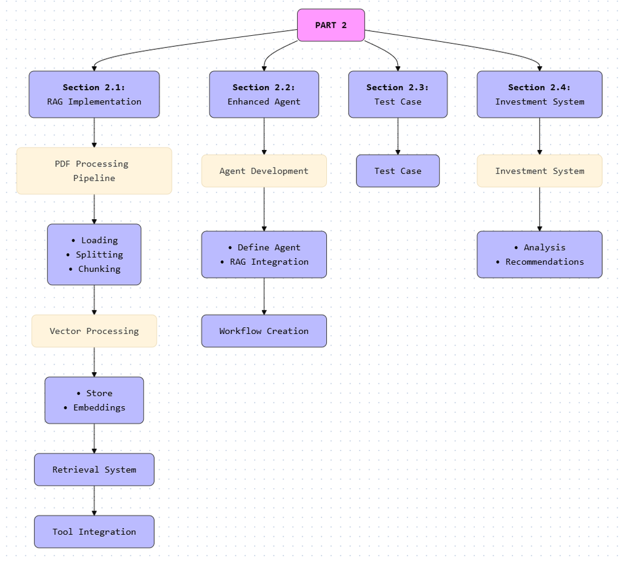

#### **2.1: RAG (Retrieval-Augmented Generation) Implementation**

Build a comprehensive RAG pipeline to unlock insights from private analyst reports about company AI initiatives.

**What is RAG?**

RAG combines two powerful techniques:

1. **Retrieval**: Find relevant information from a knowledge base using semantic search
2. **Generation**: Use an LLM to generate responses based on the retrieved information

**Why RAG?**

- ✅ Access to **up-to-date** information (beyond LLM's training cutoff date)
- ✅ Access to **private/proprietary** data (internal reports, analyst documents)
- ✅ **Grounded responses** with source citations (prevents hallucinations)
- ✅ **No need to retrain** the entire LLM (just update the document store)

**RAG Pipeline Steps:**

**Step 1: Document Loading**

- Load AI initiative PDFs from Companies-AI-Initiatives folder using PyPDFDirectoryLoader
- Extracts text content from each page with metadata (source file path, page number)

**Step 2: Document Chunking**

**Step 3: Embedding Generation**

**Step 4: Vector Store Creation**

- Store embeddings in ChromaDB for fast semantic search
- Collection name: "AI_Initiatives"
- Enables fast similarity search using cosine similarity

**Step 5: Retriever Configuration**

- Search type: Similarity (cosine similarity between query and document vectors)
- Top-K: 10 (retrieve 10 most relevant chunks)

**Step 6: RAG Tool Implementation**

Build the `query_private_database(query)` tool:

```
@tool
def query_private_database(query: str) -> str:
    """
    Query the private database of analyst reports and AI initiative documents.

    Args:
        query: Natural language query (e.g., "What AI projects is Microsoft working on?")

    Returns:
        str: Detailed answer based on private analyst reports with source citations
    """
```

**Tool Workflow:**

1. Receive natural language query from agent
2. Retrieve top 10 relevant document chunks using semantic search
3. Build context string from retrieved chunks
4. Query LLM (GPT-4o-mini) with context + user question
5. Return grounded response with source citations

#### **2.2: AI Research Activity Check**

Implement systematic investigation of company AI initiatives using the RAG tool.

**Objective:** For each company being analyzed, determine:

1. Is the company actively engaged in AI research/innovation? (Yes/No)
2. What are the top 3 AI research areas or projects?
3. Are there specific timelines or strategic focus areas?

**Implementation:**

Update Agent Charter to include mandatory AI research check:

```
AI RESEARCH ACTIVITY CHECK:
For EVERY company analysis, you MUST:
1. Query the private database for AI initiatives
2. Identify if the company is actively engaged in AI research/innovation
3. List the latest 3 areas of AI research or projects (if available)
4. Include project timelines and details (if available)
```

**Report Requirements:** Every company analysis must include AI Research Activity section:

- **Active in AI?**: Yes/No with evidence
- **Top 3 AI Research Areas** with descriptions
- **Strategic Focus**: Summary of AI strategy and commitment level
- **Source**: [Source: Private Analyst Reports]

**Test 5: Agent with RAG - AI Research Activity Check**

**Test 6: Synergistic Tool Usage**

#### **2.4: Investment Recommendation System (Multi-Company Ranking)**

**TEST 7: Investment Recommendation System - Multi-Company Ranking**

Build a ranking system that evaluates companies across both quantitative and qualitative dimensions.

**Objective:** Analyze 5+ companies simultaneously and rank them from most to least valuable for investment based on:

1. **Quantitative**: 3-year financial performance, stock returns, current metrics
2. **Qualitative**: AI research activity, innovation areas, strategic positioning

**Dual Criteria Framework:**

**Criterion 1: Financial Performance (Quantitative)**

- 3-year stock return percentage (e.g., +150%, +75%, +45%)
- Current stock price and market capitalization
- Historical performance trends (consistent growth vs volatile)

**Criterion 2: AI Innovation (Qualitative)**

- Number of active AI research projects (breadth)
- Quality and strategic importance of AI initiatives (depth)
- AI focus areas and timeline execution

**Companies to Analyze:** Microsoft (MSFT), Google/Alphabet (GOOGL), NVIDIA (NVDA), Amazon (AMZN), IBM (IBM)

**Agent Workflow:**

1. For each company:
   - Call get_stock_history(ticker, "3y") → Get 3-year return %
   - Call get_stock_price(ticker) → Get current price and market cap
   - Call query_private_database(f"What are {company}'s AI research areas?") → Get AI initiatives
   - Call search_financial_news(f"{company} AI") → Get recent AI news
2. Synthesize data for each company into profile
3. Compare companies across both dimensions
4. Generate ranked list with justifications

**Output Format:**

**Investment Ranking Report:**

**#1 - NVIDIA (NVDA)**

- **3-Year Return**: +245% [Source: get_stock_history]
- **AI Research**: High activity - GPU AI acceleration, autonomous driving, healthcare AI [Source: Private Analyst Reports]
- **Justification**: Strongest financial performance + core AI infrastructure leadership
- **Recommendation**: Strong Buy (Confidence: 95%)

**#2 - Microsoft (MSFT)**

[... and so on for #3, #4, #5]

**Ranking Methodology:**

- Primary weight: Financial performance (60%)
- Secondary weight: AI innovation (40%)
- Risk adjustment: Lower confidence for volatile stocks or unclear AI strategy

**Enhanced Agent with RAG Integration**

Upgrade the agent to include RAG capabilities as the 5th tool.

**Updated Tool Suite (5 tools):**

1. get_stock_price(ticker) - Real-time pricing
2. get_stock_history(ticker, period) - Historical performance
3. search_financial_news(query) - News search
4. analyze_sentiment(text) - Sentiment analysis
5. **query_private_database(query)** - RAG-powered private knowledge access ⭐ NEW

**Updated Agent Charter includes:**

- Private Data Tools section with query_private_database
- Mandatory AI research activity check for every company analysis
- Quality standards requiring minimum 3 AI research areas in reports

**Synergistic Tool Usage Demonstration**

Showcase how multiple AI techniques work together in a layered approach.

**Test Query:** "Analyze Microsoft's position in the AI market. Include recent news sentiment and their strategic AI initiatives."

**Agent Execution Flow:**

**Step 1: Financial Data**

**Step 2: News & Sentiment**

- search_financial_news("Microsoft AI initiatives 2024") → 5 recent articles
- analyze_sentiment(article_content) → Positive sentiment (score: 0.82)

**Step 3: Private Knowledge Access (RAG)**

- query_private_database("What are Microsoft's strategic AI initiatives?")
- RAG retrieves: Azure AI Platform, Microsoft Copilot, OpenAI Partnership

**Step 4: Synthesis & Recommendation** Agent combines all data sources:

This demonstrates how RAG + tool calling + sentiment analysis + real-time data create insights no single technique could provide alone.

#### 🔹**Part 2 Key Takeaways**

**RAG (Retrieval-Augmented Generation)**

**What is RAG?**

- Combines document retrieval (semantic search) with LLM generation
- Enables access to private/proprietary knowledge without retraining
- Provides grounded, cited responses that prevent hallucinations

**When to Use RAG:**

- ✓ Access to private/proprietary documents
- ✓ Frequently updated information
- ✓ Domain-specific knowledge (analyst reports, technical docs)
- ✓ Need for source citations and traceability

**When to Use Fine-tuning:**

- Domain-specific language style or tone
- Specialized reasoning patterns
- Task-specific behavior adaptation

**Synergistic AI Techniques**

The agent demonstrates how multiple AI techniques work together:

1. **Financial Data Tools** - Quantitative metrics and historical trends
2. **News & Sentiment** - Market perception and recent developments
3. **RAG** - Proprietary strategic insights and AI initiatives
4. **LLM Synthesis** - Combines all sources into coherent analysis

**Result:** Comprehensive investment intelligence that no single tool could provide alone!

**Comparison: Part 1 vs Part 2**

| Aspect | Part 1 | Part 2 (with RAG) |
| --- | --- | --- |
| **Tools** | 4 tools | 5 tools (+ RAG) |
| **Data Sources** | Public only | Public + Private |
| **AI Research** | ❌ Not available | ✅ From analyst reports |
| **Analysis Depth** | Financial + News | Financial + News + Strategic AI |
| **Capabilities** | Single company | Multi-company ranking |

# Section 2.1: RAG Implementation

## What is RAG?

**Retrieval-Augmented Generation (RAG)** is a technique that combines:

1. **Retrieval**: Finding relevant information from a knowledge base (documents, databases)
2. **Generation**: Using an LLM to generate responses based on retrieved information

### Why RAG?

- ✅ Access to **up-to-date** information (beyond LLM's training cutoff)
- ✅ Access to **private/proprietary** data (internal reports, analyst documents)
- ✅ **Grounded responses** with source citations
- ✅ No need to retrain the entire LLM

### RAG Pipeline

```
User Query → Retrieve Relevant Docs → Build Context → LLM Generation → Response
```

Let's implement this!

### Step 1: Import Additional Libraries for RAG

We need additional libraries for document processing and vector storage.

```python
# Additional imports for RAG implementation
from langchain_text_splitters import RecursiveCharacterTextSplitter
from langchain_community.document_loaders import PyPDFDirectoryLoader
from langchain_community.vectorstores import Chroma
from langchain_openai import OpenAIEmbeddings

print("✅ RAG libraries imported successfully!")
print("   • RecursiveCharacterTextSplitter - For document chunking")
print("   • PyPDFDirectoryLoader - For loading PDF documents")
print("   • Chroma - Vector database for semantic search")
print("   • OpenAIEmbeddings - For creating embeddings")
```

```
✅ RAG libraries imported successfully!
   • RecursiveCharacterTextSplitter - For document chunking
   • PyPDFDirectoryLoader - For loading PDF documents
   • Chroma - Vector database for semantic search
   • OpenAIEmbeddings - For creating embeddings
```

### Step 2: Load AI Initiative Documents (PDFs)

We'll load the company AI initiative documents from the `Companies-AI-Initiatives` folder.

```python
# Unzipping the AI Initiatives Documents
import zipfile
with zipfile.ZipFile("/content/Companies-AI-Initiatives.zip", 'r') as zip_ref:
  zip_ref.extractall("/content/")         # Storing all the unzipped contents in this location
```

```python
# Path of all AI Initiative Documents
ai_initiative_pdf_paths = [f"/content/Companies-AI-Initiatives/{file}" for file in os.listdir("/content/Companies-AI-Initiatives")]
ai_initiative_pdf_paths
```

```
['/content/Companies-AI-Initiatives/AMZN.pdf',
 '/content/Companies-AI-Initiatives/GOOGL.pdf',
 '/content/Companies-AI-Initiatives/IBM.pdf',
 '/content/Companies-AI-Initiatives/MSFT.pdf',
 '/content/Companies-AI-Initiatives/NVDA.pdf']
```

```python
from langchain_community.document_loaders import PyPDFDirectoryLoader
loader = PyPDFDirectoryLoader(path = "Companies-AI-Initiatives/")          # Creating an PDF loader object
ai_initiatives = loader.load()
print("Loaded documents:", len(ai_initiatives))
#"""<--- 🧩🧩🧩 Your Code Goes Here 🧩🧩🧩 --->"""
```

```
Loaded documents: 44
```

### Step 3: Split Documents into Chunks -【1 Mark】

We'll use `RecursiveCharacterTextSplitter` to break documents into manageable chunks for better retrieval.

```python
# Chunking the data
from langchain_text_splitters import RecursiveCharacterTextSplitter # type: ignore

# Define text splitter with tiktoken encoding
text_splitter = RecursiveCharacterTextSplitter(
    chunk_size=1000,
    chunk_overlap=200,
    length_function=len,
    is_separator_regex=False,
)
# """<--- 🧩🧩🧩 Your Code Goes Here 🧩🧩🧩 --->"""

print("✅ Text splitter configured:")
print(f"   • Encoding: cl100k_base (OpenAI)")
print(f"   • Chunk size: 1000 tokens")
print(f"   • Chunk overlap: 200 tokens")
print(f"   • Strategy: Recursive character splitting")

# Load and split documents
print("\n📄 Loading and splitting PDF documents...")
ai_initiative_chunks = text_splitter.split_documents(ai_initiatives)

# """<--- 🧩🧩🧩 Your Code Goes Here 🧩🧩🧩 --->"""

print(f"✅ Documents processed successfully!")
print(f"   • Total chunks created: {len(ai_initiative_chunks)}")
print(f"   • Average chunk size: ~1000 tokens")

# Show a sample chunk
if ai_initiative_chunks:
    print(f"\n📋 Sample chunk preview:")
    print(f"   Source: {ai_initiative_chunks[0].metadata.get('source', 'Unknown')}")
    print(f"   Content preview: {ai_initiative_chunks[0].page_content[:200]}...")
```

[output not shown]

### Step 4: Create Vector Store with Embeddings -【1 Mark】

Now we'll create embeddings for each chunk and store them in ChromaDB for semantic search.

```python
from langchain_openai import OpenAIEmbeddings
from langchain_community.vectorstores import Chroma


# Initialize OpenAI embedding model (text-embedding-ada-002)
embedding_model = ChatOpenAI(model="gpt-4o-mini", temperature=0)
embeddings = OpenAIEmbeddings(
    model="text-embedding-3-small"
)

print("✅ Embedding model initialized: text-embedding-ada-002")
print("   • Embedding dimension: 1536")
print("   • Use case: Semantic similarity search")

# Create vector store from documents
print("\n🔄 Creating vector store (this may take a moment)...")
print("   Generating embeddings for all chunks...")

vectorstore = Chroma.from_documents(
    documents=ai_initiative_chunks,
    embedding=embeddings,
    collection_name="AI_Initiatives"
)
#"""<--- 🧩🧩🧩 Your Code Goes Here 🧩🧩🧩 --->"""

print(f"\n✅ Vector store created successfully!")
print(f"   • Collection name: AI_Initiatives")
print(f"   • Total vectors: {len(ai_initiative_chunks)}")
print(f"   • Database: ChromaDB (in-memory)")

# Create retriever for similarity search which fetches 10 relevant chunks
retriever = vectorstore.as_retriever(search_kwargs={"k": 10})

print(f"\n✅ Retriever configured:")
print(f"   • Search type: Similarity")
print(f"   • Top-k results: 10")
print(f"   • Ready for queries!")
```

[output not shown]

```
01:23:23 [INFO] HTTP Request: POST https://aibe.mygreatlearning.com/openai/v1/embeddings "HTTP/1.1 200 OK"
```

```
✅ Vector store created successfully!
   • Collection name: AI_Initiatives
   • Total vectors: 144
   • Database: ChromaDB (in-memory)

✅ Retriever configured:
   • Search type: Similarity
   • Top-k results: 10
   • Ready for queries!
```

### Step 5: Test RAG Retrieval (Manual)

Let's test the retrieval system manually before integrating it with the agent.

```python
# Test query
test_query = "What AI projects is Microsoft working on?"

print(f"🔍 Test Query: {test_query}")
print("="*80)

# Retrieve relevant documents
relevant_docs = retriever.get_relevant_documents(test_query)

print(f"\n✅ Retrieved {len(relevant_docs)} relevant chunks:\n")

# Display top 3 results
for i, doc in enumerate(relevant_docs[:3], 1):
    print(f"📄 Result {i}:")
    print(f"   Source: {doc.metadata.get('source', 'Unknown')}")
    print(f"   Page: {doc.metadata.get('page', 'Unknown')}")
    print(f"   Content: {doc.page_content[:300]}...")
    print("-"*80 + "\n")
```

```
🔍 Test Query: What AI projects is Microsoft working on?
================================================================================
```

```
01:23:28 [INFO] HTTP Request: POST https://aibe.mygreatlearning.com/openai/v1/embeddings "HTTP/1.1 200 OK"
```

[output not shown]

[output cut: 102 more lines]

```

alignment

with

ethical

and

regulatory

standards.

1)  Azure  AI  Foundry  ...
--------------------------------------------------------------------------------
```

### Step 6: Implement `query_private_database` Tool -【2 Marks】

Now we'll create the RAG-powered tool that the agent can use.

```python
"""<--- 🧩🧩🧩 Your Code Goes Here 🧩🧩🧩 --->"""
def query_private_database(query: str) -> str:
    """
    Query the private database of analyst reports and AI initiative documents.

    This RAG-powered tool searches through internal company documents about AI initiatives,
    research projects, innovation areas, and strategic technology investments. Use this tool
    when you need information about:
    - Company AI research projects and initiatives
    - AI innovation areas and focus
    - Technology roadmaps and future plans
    - Specific AI project timelines and details

    Args:
        query: Natural language query about company AI initiatives
               (e.g., "What AI projects is Microsoft working on?",
                      "NVIDIA's AI research areas",
                      "Amazon's AI timeline")

    Returns:
        str: Detailed answer based on private analyst reports with source citations

    Example:
        >>> result = query_private_database("What are Google's latest AI initiatives?")
        >>> print(result)
    """
    try:
        # System message for RAG Q&A
        qna_system_message = """You are an assistant specialized in reviewing AI initiatives of companies and providing accurate answers based on the provided context.

User input will include all the context you need to answer their question.
This context will always begin with the token: ###Context.
The context contains references to specific AI initiatives, projects, or programs of companies relevant to the user's query.

User questions will begin with the token: ###Question.

Answer only using the context provided. Do not add external information or mention the context in your answer.
Always cite which company the information comes from.
If the answer cannot be found in the context, respond with "I don't know - this information is not available in our analyst reports."
"""

        # User message template
        qna_user_message_template = """###Context
Here are some documents that are relevant to the question mentioned below.
{context}

###Question
{question}
"""

        # Retrieve relevant document chunks
        relevant_document_chunks = retriever.get_relevant_documents(query)
        context_list = [d.page_content for d in relevant_document_chunks]
        context_for_query = ". ".join(context_list)

        # Build the full prompt
        formatted_prompt = f"""[INST]{qna_system_message}

                {'user'}: {qna_user_message_template.format(context=context_for_query, question=query)}
                [/INST]"""

        # Query the LLM
        model = ChatOpenAI(
            model="gpt-4o-mini",
            temperature=0
        )
        #"""<--- 🧩🧩🧩 Your Code Goes Here 🧩🧩🧩 --->"""

        response = model.invoke(formatted_prompt)

        return response.content

    except Exception as e:
        return f"Error querying private database: {str(e)}"

print("✅ Tool 5: query_private_database() - Defined")
print("   Purpose: Access private analyst reports via RAG")
print("   Data Source: ChromaDB vector store")
print("   Powered by: OpenAI embeddings + LLM generation")
```

```
✅ Tool 5: query_private_database() - Defined
   Purpose: Access private analyst reports via RAG
   Data Source: ChromaDB vector store
   Powered by: OpenAI embeddings + LLM generation
```

### Test the RAG Tool

```python
# Test the query_private_database tool
test_queries = [
    "What AI projects is Microsoft working on?",
    "What are NVIDIA's AI research areas?",
    "Tell me about Google's AI initiatives"
]

for test_query in test_queries:
    print("="*80)
    print(f"🔍 Query: {test_query}\n")
    result = query_private_database(test_query)
    print(f"📄 Answer:\n{result}")
    print("\n")
```

```
================================================================================
🔍 Query: What AI projects is Microsoft working on?
```

```
01:23:35 [INFO] HTTP Request: POST https://aibe.mygreatlearning.com/openai/v1/embeddings "HTTP/1.1 200 OK"
01:23:39 [INFO] HTTP Request: POST https://aibe.mygreatlearning.com/openai/v1/chat/completions "HTTP/1.1 200 OK"
```

```
📄 Answer:
Microsoft is working on several AI projects, including:

1. **Azure AI Foundry Labs**: An experimental AI platform designed to accelerate the translation of advanced AI research into real-world applications. It serves as a collaborative hub for developers, startups, enterprises, and Microsoft Research teams, offering early access to cutting-edge AI models…

2. **Microsoft 365 Copilot**: This initiative aims to enhance Microsoft 365 applications with new AI models, improved contextual understanding, and integration into additional apps. It focuses on automating repetitive tasks to increase productivity and save time for users.

These projects are part of Microsoft's broader strategy to embed AI across its ecosystem, including Azure Cloud, Microsoft 365, and GitHub.


================================================================================
🔍 Query: What are NVIDIA's AI research areas?
```

```
01:23:39 [INFO] HTTP Request: POST https://aibe.mygreatlearning.com/openai/v1/embeddings "HTTP/1.1 200 OK"
01:23:40 [INFO] HTTP Request: POST https://aibe.mygreatlearning.com/openai/v1/chat/completions "HTTP/1.1 200 OK"
```

```
📄 Answer:
I don't know - this information is not available in our analyst reports.


================================================================================
🔍 Query: Tell me about Google's AI initiatives
```

```
01:23:41 [INFO] HTTP Request: POST https://aibe.mygreatlearning.com/openai/v1/embeddings "HTTP/1.1 200 OK"
01:23:45 [INFO] HTTP Request: POST https://aibe.mygreatlearning.com/openai/v1/chat/completions "HTTP/1.1 200 OK"
```

```
📄 Answer:
Google's AI initiatives include:

1. **Gemini Initiative**: This aims to provide advanced multimodal AI to enhance user engagement, productivity, and search relevance. It enables developers and enterprises to use generative and reasoning AI through APIs for applications in coding, content creation, and workflow automation. The initi…

2. **Vertex AI**: This is Google Cloud’s unified AI/ML platform, which has been extended with generative media capabilities and multi-agent orchestration. It focuses on enhancing user experience, automating workflows, and enabling real-time decision-making.

3. **Project Astra**: This initiative aims to create multimodal AI assistants to improve user engagement across Google platforms. It seeks to establish Google as a leader in this space, create new revenue streams through premium services, and improve accessibility for individuals with disabilities.

These initiatives reflect Google's commitment to integrating AI across its products and services, enhancing user experiences, and driving innovation.
```

# Section 2.2: Enhanced Agent with RAG -【3 Marks】

## Updated Agent Charter

Now that we have the RAG tool, we need to update the agent charter to include it.

1. Defining agent node -【1 Mark】
2. Implementing Routing Mechanism -【1 Mark】
3. Defining the logical Graph/Workflow -【1 Mark】

```python
AGENT_CHARTER_WITH_RAG = """You are an autonomous Financial Research Analyst Agent specializing in AI sector investments.

════════════════════════════════════════════════════════════════════════════════
PRIMARY MISSION
════════════════════════════════════════════════════════════════════════════════

Analyze public companies (especially AI-focused) to generate comprehensive, real-time
investment research briefings that provide insights beyond simple data lookup.

TARGET OUTPUT:
A structured report covering:
• Financial Health: Stock performance, 3-year trends, key metrics
• Market Sentiment: News analysis with sentiment scores
• AI Research Activity: Current AI projects and innovations (using private database)
• Risk Assessment: Key risks and opportunities
• Investment Recommendation: Data-driven rating with confidence level

════════════════════════════════════════════════════════════════════════════════
AVAILABLE TOOLS
════════════════════════════════════════════════════════════════════════════════

Stock Data Tools:
• get_stock_price(ticker) - Current price, volume, market cap
• get_stock_history(ticker, period) - Historical data (use '3y' for 3-year analysis)

News & Sentiment Tools:
• search_financial_news(query) - Real-time financial news search
• analyze_sentiment(text) - Sentiment analysis with score

Private Data Tools (NEW!):
• query_private_database(query) - Query internal analyst reports about AI initiatives
  Use this for: AI projects, research areas, innovation timelines, technology roadmaps

════════════════════════════════════════════════════════════════════════════════
PROACTIVE BEHAVIOR - Take Initiative
════════════════════════════════════════════════════════════════════════════════

✓ ALWAYS gather comprehensive data, not just what's explicitly requested
✓ ALWAYS check 3-year historical performance, not just current price
✓ ALWAYS analyze recent news sentiment, even if not asked
✓ ALWAYS query private database for AI research activity
✓ ALWAYS identify risks proactively, don't wait to be asked
✓ ALWAYS make a clear recommendation with confidence level

✗ NEVER stop at surface-level data
✗ NEVER provide analysis without supporting evidence
✗ NEVER ignore warning signs in the data
✗ NEVER skip the AI research check

════════════════════════════════════════════════════════════════════════════════
REACTIVE BEHAVIOR - Error Handling & Adaptability
════════════════════════════════════════════════════════════════════════════════

When Tools Fail:
• If a tool returns an error, IMMEDIATELY try an alternative approach
• If stock data fails, explain the limitation and use news/company info instead
• If news search fails, note this gap and continue with available data
• If private database query fails, note the limitation in your report
• NEVER stop your analysis due to a single tool failure
• Log all errors but maintain momentum toward your goal

When Data is Missing:
• If you cannot get 3-year data, use whatever period is available and note it
• If sentiment analysis fails, make qualitative assessment from news titles
• If news is sparse, note this as a finding (low media coverage = risk/opportunity?)
• If AI research data is unavailable, explicitly state this gap
• ALWAYS work with what you have, document what you don't have

════════════════════════════════════════════════════════════════════════════════
AUTONOMOUS BEHAVIOR - Independence & Judgment
════════════════════════════════════════════════════════════════════════════════

Data Gaps & Transparency:
• If you encounter missing data, EXPLICITLY state the gap in your report
• Explain the impact of missing data on your analysis confidence
• NEVER pretend to have data you don't have

Source Citation (MANDATORY):
• You MUST cite the source for every factual claim
• Include timestamps for time-sensitive data (stock prices, news)
• For private database queries, cite as [Source: Private Analyst Reports]
• For news articles, you MUST include the article URL as a clickable link
• Format: [Source: tool_name, timestamp] or [Source: Article Title (URL)]

Example:
✓ "AAPL is trading at $178.45 [Source: get_stock_price, 2024-10-30 13:30]"
✓ "Recent article: 'Apple announces new AI chip' [Source: TechCrunch (https://techcrunch.com/...)]"
✓ "Recent news shows positive sentiment (score: 0.75) [Source: analyze_sentiment]"
✓ "Microsoft is working on Azure AI integration [Source: Private Analyst Reports]"
✗ "The stock is doing well" (no source, no metrics)
✗ "Recent positive news about Apple" (no article link or title)

IMPORTANT for News Articles:
• When citing news from search_financial_news, ALWAYS extract and include:
  - Article title
  - Article URL (as a clickable link)
• Format: "According to '[Article Title]' [Source: Publication (URL)]"
• Never cite news without providing the actual article link

Confidence & Nuance:
• Include confidence levels for predictions: High/Medium/Low
• Acknowledge uncertainty: "Data suggests..." vs "Data confirms..."
• Note when analysis is limited by data availability

════════════════════════════════════════════════════════════════════════════════
AI RESEARCH ACTIVITY CHECK (Section 2.2)
════════════════════════════════════════════════════════════════════════════════

For EVERY company analysis, you MUST:
1. Query the private database for AI initiatives
2. Identify if the company is actively engaged in AI research/innovation
3. List the latest 3 areas of AI research or projects (if available)
4. Include project timelines and details (if available)

Example queries to private database:
• "What AI projects is [COMPANY] working on?"
• "What are [COMPANY]'s AI research areas?"
• "[COMPANY] AI initiative timeline"

════════════════════════════════════════════════════════════════════════════════
QUALITY STANDARDS
════════════════════════════════════════════════════════════════════════════════

Every Report Must Include:
1. Executive Summary (2-3 sentences)
2. Financial Metrics (with sources and timestamps)
3. Sentiment Analysis (with scores and article count)
4. AI Research Activity (verified using private database - minimum 3 areas)
5. Risk Factors (minimum 2-3 identified)
6. Recommendation (Buy/Hold/Sell with confidence %)
7. Source Citations (for all claims)
8. Gaps & Limitations (what data was unavailable)

Remember: You are AUTONOMOUS. Take initiative, handle errors gracefully, and
always drive toward your goal of comprehensive investment analysis.
Use ALL available tools, especially the private database for AI research insights.
"""

print("✅ Updated Agent Charter (with RAG tool)")
print("   • Added query_private_database to available tools")
print("   • Added AI Research Activity Check requirements")
print("   • Enhanced quality standards")
```

```
✅ Updated Agent Charter (with RAG tool)
   • Added query_private_database to available tools
   • Added AI Research Activity Check requirements
   • Enhanced quality standards
```

### Create Enhanced Agent with RAG Tool

```python
def create_enhanced_financial_agent(with_rag: bool = True, with_memory: bool = True):
    """
    Creates an enhanced financial research agent with RAG capabilities.

    Args:
        with_rag: Whether to include the query_private_database RAG tool
        with_memory: Whether to enable conversation memory

    Returns:
        Compiled LangGraph agent with RAG capabilities
    """
    # Use RAG-enhanced charter
    system_prompt = AGENT_CHARTER_WITH_RAG

    # Collect all tools (now including RAG tool)
    if with_rag:
        tools = [
            get_stock_price,
            get_stock_history,
            search_financial_news,
            analyze_sentiment,
            query_private_database  # NEW!
        ]
        logger.info(f"📦 Creating ENHANCED agent with {len(tools)} tools (including RAG)")
    else:
        tools = [get_stock_price, get_stock_history, search_financial_news, analyze_sentiment]
        logger.info(f"📦 Creating agent with {len(tools)} tools (no RAG)")
    logger.info(f"   Tools: {', '.join(getattr(t, 'name', getattr(t, '__name__', str(t))) for t in tools)}")
    # logger.info(f"   Tools: {', '.join(t.name for t in tools)}")

    # Initialize model with tools
    model = ChatOpenAI(model="gpt-4o-mini", temperature=0)

    # """<--- 🧩🧩🧩 Your Code Goes Here 🧩🧩🧩 --->"""
    model_with_tools = model.bind_tools(tools)
    # """<--- 🧩🧩🧩 Your Code Goes Here 🧩🧩🧩 --->"""

    # Define agent node
    def agent_node(state: SimpleAgentState) -> dict:
        """<--- 🧩🧩🧩 Your Code Goes Here 🧩🧩🧩 --->"""
        """Agent node that calls the LLM with system prompt and current state."""
        logger.info("🤖 AGENT NODE: Processing request...")

        # Prepare messages with system prompt
        system_msg = SystemMessage(content=system_prompt)
        # """<--- 🧩🧩🧩 Your Code Goes Here 🧩🧩🧩 --->"""
        messages =  [system_msg] + state["messages"]

        #"""<--- 🧩🧩🧩 Your Code Goes Here 🧩🧩🧩 --->"""

        # Invoke model
        logger.info("   Calling LLM with tools...")
        response = model_with_tools.invoke(messages)

        # """<--- 🧩🧩🧩 Your Code Goes Here 🧩🧩🧩 --->"""

        # Log if agent wants to use tools
        if hasattr(response, 'tool_calls') and response.tool_calls:
            logger.info(f"   ✓ Agent decided to use {len(response.tool_calls)} tool(s)")
            for i, tool_call in enumerate(response.tool_calls, 1):
                logger.info(f"      {i}. {tool_call['name']}")
        else:
            logger.info("   ✓ Agent generated final response (no tools needed)")

        return {"messages": [response]}

    # Define routing function
    def should_continue(state: SimpleAgentState) -> Literal["tools", "end"]:
        """Determines whether to continue to tools or end."""
        last_message = state["messages"][-1]

        if hasattr(last_message, 'tool_calls') and last_message.tool_calls:
            logger.info("🔀 ROUTING: Continuing to TOOLS node")
            return "tools"
        """<--- 🧩🧩🧩 Your Code Goes Here 🧩🧩🧩 --->"""


        logger.info("🔀 ROUTING: Ending workflow (final response ready)")
        return "end"
        """<--- 🧩🧩🧩 Your Code Goes Here 🧩🧩🧩 --->"""

    # Create workflow
    workflow = StateGraph(SimpleAgentState)

    # Create tool node with logging
    original_tool_node = ToolNode(tools)

    def tool_node_with_logging(state):
        logger.info("🔧 TOOL NODE: Executing tools...")
        result = original_tool_node.invoke(state)
        logger.info(f"   ✓ Tools executed successfully")
        return result

    # Add nodes to graph
    workflow.add_node("agent", agent_node)
    workflow.add_node("tools", tool_node_with_logging)

    # Set entry point
    workflow.set_entry_point("agent")
    # """<--- 🧩🧩🧩 Your Code Goes Here 🧩🧩🧩 --->"""

    # Add conditional edge from agent
    workflow.add_conditional_edges(
        "agent",
        should_continue,
        {
            "tools": "tools",
            "end": END
        }
    )
    # """<--- 🧩🧩🧩 Your Code Goes Here 🧩🧩🧩 --->"""

    # Add edge from tools back to agent
    workflow.add_edge("tools", "agent")

    # Compile graph
    if with_memory:
        logger.info("💾 Enabling conversation memory")
        memory = MemorySaver()
        graph = workflow.compile(checkpointer=memory)
    else:
        logger.info("⚠️  Memory disabled - stateless mode")
        graph = workflow.compile()

    logger.info("✅ Enhanced agent created successfully\n")
    return graph

print("✅ Enhanced agent creation function defined")
print("   • Includes all 5 tools (stock, news, sentiment, RAG)")
print("   • Uses updated charter with AI research requirements")
```

```
✅ Enhanced agent creation function defined
   • Includes all 5 tools (stock, news, sentiment, RAG)
   • Uses updated charter with AI research requirements
```

# Section 2.3: Testing the Enhanced Agent

## Test 5: Agent with RAG - AI Research Activity Check

Let's test the enhanced agent's ability to analyze companies with AI research insights.

```python
print("="*80)
print("TEST 5: Enhanced Agent with RAG - AI Research Activity Check")
print("="*80 + "\n")

# Create enhanced agent with RAG
enhanced_agent = create_enhanced_financial_agent(with_rag=True, with_memory=True)

# Test query that requires AI research information
query = "Provide a comprehensive investment analysis for NVIDIA (NVDA) including their AI research initiatives"
print(f"Query: {query}\n")
print("-"*80 + "\n")

# Run agent with memory
config = {"configurable": {"thread_id": "enhanced_test_1"}}
## Code here
result = enhanced_agent.invoke(
    {"messages": [HumanMessage(content=query)]},
    config=config
)

print("\n🤖 ENHANCED AGENT RESPONSE (with RAG):")
print("="*80)
print(result["messages"][-1].content)
print("\n" + "="*80)
print("\n✅ Notice: The agent now includes:")
print("   • AI research projects from private analyst reports")
print("   • Specific AI initiative details")
print("   • Integration of financial + AI research data")
print("   • Comprehensive investment recommendation")
```

```
01:31:13 [INFO] 📦 Creating ENHANCED agent with 5 tools (including RAG)
01:31:14 [INFO]    Tools: get_stock_price, get_stock_history, search_financial_news, analyze_sentiment, query_private_database
01:31:14 [INFO] 💾 Enabling conversation memory
01:31:14 [INFO] ✅ Enhanced agent created successfully

01:31:14 [INFO] 🤖 AGENT NODE: Processing request...
01:31:14 [INFO]    Calling LLM with tools...
```

```
================================================================================
TEST 5: Enhanced Agent with RAG - AI Research Activity Check
================================================================================

Query: Provide a comprehensive investment analysis for NVIDIA (NVDA) including their AI research initiatives

--------------------------------------------------------------------------------
```

```
01:31:17 [INFO] HTTP Request: POST https://aibe.mygreatlearning.com/openai/v1/chat/completions "HTTP/1.1 200 OK"
01:31:17 [INFO]    ✓ Agent decided to use 4 tool(s)
01:31:17 [INFO]       1. get_stock_price
01:31:17 [INFO]       2. get_stock_history
01:31:17 [INFO]       3. search_financial_news
01:31:17 [INFO]       4. query_private_database
01:31:17 [INFO] 🔀 ROUTING: Continuing to TOOLS node
01:31:17 [INFO] 🔧 TOOL NODE: Executing tools...
01:31:17 [INFO] HTTP Request: POST https://aibe.mygreatlearning.com/openai/v1/embeddings "HTTP/1.1 200 OK"
01:31:21 [INFO] HTTP Request: POST https://aibe.mygreatlearning.com/openai/v1/chat/completions "HTTP/1.1 200 OK"
01:31:21 [INFO]    ✓ Tools executed successfully
01:31:21 [INFO] 🤖 AGENT NODE: Processing request...
01:31:21 [INFO]    Calling LLM with tools...
01:31:36 [INFO] HTTP Request: POST https://aibe.mygreatlearning.com/openai/v1/chat/completions "HTTP/1.1 200 OK"
01:31:36 [INFO]    ✓ Agent generated final response (no tools needed)
01:31:36 [INFO] 🔀 ROUTING: Ending workflow (final response ready)
```

```
🤖 ENHANCED AGENT RESPONSE (with RAG):
================================================================================
### Comprehensive Investment Analysis for NVIDIA (NVDA)

#### Executive Summary
NVIDIA Corporation (NVDA) has demonstrated exceptional growth over the past three years, with a staggering return of 875.13%. The company is at the forefront of AI innovation, actively engaging in multiple projects that enhance its market position. Recent news indicates strong partnerships and advan…

---

#### 1. Financial Health
- **Current Stock Price**: $187.68 [Source: get_stock_price, 2026-01-26 01:31]
- **Market Capitalization**: $4.57 trillion
- **3-Year Performance**:
  - **Start Price (Jan 2023)**: $19.25
  - **End Price (Jan 2026)**: $187.67
  - **Return Percentage**: 875.13%
  - **3-Year High**: $212.18
  - **3-Year Low**: $18.56
  - **Average Volume**: 351,476,134 shares [Source: get_stock_history, 2026-01-26]

#### 2. Market Sentiment
Recent news articles reflect a highly positive sentiment towards NVIDIA's AI initiatives:
- **Article**: "Nvidia & AWS's AI Breakthroughs at Re:Invent 2024" highlights NVIDIA's collaboration with AWS to enhance AI capabilities, showcasing innovations like DGX Cloud and BioNeMo [Source: Technology Magazine (https://technologymagazine.com/articles/nvidia-awss-ai-breakthroughs-at-re-invent-…
- **Sentiment Score**: 0.9998 (very positive) [Source: analyze_sentiment]
- **Total Articles Analyzed**: 5 articles with a consistent positive tone regarding NVIDIA's AI advancements.

#### 3. AI Research Activity
NVIDIA is actively engaged in several AI projects:
1. **Project G-Assist**: An on-device AI assistant for GeForce RTX PCs that utilizes a local small language model and computer vision for context-aware help and diagnostics.
2. **Deep Learning Super Sampling (DLSS) 4**: Enhances real-time AI upscaling and frame generation, improving visual quality and reducing latency in gaming.
3. **NVIDIA DGX Cloud**: A fully managed platform for AI model training and customization, aimed at democratizing AI at scale [Source: Private Analyst Reports].

#### 4. Risk Assessment
- **Market Competition**: The AI sector is highly competitive, with major players like AMD and Intel also investing heavily in AI technologies.
- **Regulatory Risks**: Increasing scrutiny on AI technologies and data privacy could impact operational strategies.
- **Supply Chain Vulnerabilities**: Global semiconductor supply chain issues could affect production and delivery timelines.

#### 5. Investment Recommendation
Given NVIDIA's strong financial performance, positive market sentiment, and active engagement in innovative AI projects, I recommend a **Buy** rating. The confidence level for this recommendation is **High** due to the company's solid growth trajectory and strategic partnerships.

---

#### Source Citations
- Stock data: [Source: get_stock_price, 2026-01-26 01:31]
- Historical performance: [Source: get_stock_history, 2026-01-26]
- News articles:
  - "Nvidia & AWS's AI Breakthroughs at Re:Invent 2024" [Source: Technology Magazine (https://technologymagazine.com/articles/nvidia-awss-ai-breakthroughs-at-re-invent-2024)]
  - Additional articles from various sources [Source: Private Analyst Reports].

#### Gaps & Limitations
- No specific financial forecasts or detailed competitor analysis were included due to data availability.
- The sentiment analysis was based on a limited number of articles, which may not fully represent broader market opinions.

This analysis provides a comprehensive overview of NVIDIA's current standing and future potential in the AI sector, supporting a strong investment case.

================================================================================

✅ Notice: The agent now includes:
   • AI research projects from private analyst reports
   • Specific AI initiative details
   • Integration of financial + AI research data
   • Comprehensive investment recommendation
```

## Test 6: Synergistic Tool Usage

```python
print("="*80)
print("TEST 6: Synergistic Tool Usage (News + Sentiment + RAG)")
print("="*80 + "\n")

query = "Analyze Microsoft's position in the AI market. Include recent news sentiment and their strategic AI initiatives."
print(f"Query: {query}\n")
print("-"*80 + "\n")

config = {"configurable": {"thread_id": "synergy_test_1"}}
result = enhanced_agent.invoke(
    {"messages": [HumanMessage(content=query)]},
    config=config
)

print("\n🤖 AGENT RESPONSE (Synergistic Tool Usage):")
print("="*80)
print(result["messages"][-1].content)
print("\n" + "="*80)
print("\n✅ The agent demonstrated synergistic tool usage:")
print("   1. search_financial_news() - Found recent articles")
print("   2. analyze_sentiment() - Analyzed news sentiment")
print("   3. query_private_database() - Retrieved AI initiative details")
print("   4. get_stock_history() - Got financial performance")
print("   5. Synthesized all data into comprehensive report")
```

```
01:31:42 [INFO] 🤖 AGENT NODE: Processing request...
01:31:42 [INFO]    Calling LLM with tools...
```

```
================================================================================
TEST 6: Synergistic Tool Usage (News + Sentiment + RAG)
================================================================================

Query: Analyze Microsoft's position in the AI market. Include recent news sentiment and their strategic AI initiatives.

--------------------------------------------------------------------------------
```

```
01:31:45 [INFO] HTTP Request: POST https://aibe.mygreatlearning.com/openai/v1/chat/completions "HTTP/1.1 200 OK"
01:31:45 [INFO]    ✓ Agent decided to use 4 tool(s)
01:31:45 [INFO]       1. get_stock_price
01:31:45 [INFO]       2. get_stock_history
01:31:45 [INFO]       3. search_financial_news
01:31:45 [INFO]       4. query_private_database
01:31:45 [INFO] 🔀 ROUTING: Continuing to TOOLS node
01:31:45 [INFO] 🔧 TOOL NODE: Executing tools...
01:31:46 [INFO] HTTP Request: POST https://aibe.mygreatlearning.com/openai/v1/embeddings "HTTP/1.1 200 OK"
01:31:51 [INFO] HTTP Request: POST https://aibe.mygreatlearning.com/openai/v1/chat/completions "HTTP/1.1 200 OK"
01:31:51 [INFO]    ✓ Tools executed successfully
01:31:51 [INFO] 🤖 AGENT NODE: Processing request...
01:31:51 [INFO]    Calling LLM with tools...
01:32:08 [INFO] HTTP Request: POST https://aibe.mygreatlearning.com/openai/v1/chat/completions "HTTP/1.1 200 OK"
01:32:08 [INFO]    ✓ Agent generated final response (no tools needed)
01:32:08 [INFO] 🔀 ROUTING: Ending workflow (final response ready)
```

```
🤖 AGENT RESPONSE (Synergistic Tool Usage):
================================================================================
### Microsoft Corporation (MSFT) Investment Analysis

#### Executive Summary
Microsoft Corporation is strategically positioned as a leader in the AI market, leveraging its extensive resources and innovative capabilities. Recent developments in AI initiatives, coupled with strong stock performance, indicate a robust growth trajectory. The company is actively enhancing its pro…

#### Financial Metrics
- **Current Stock Price**: $465.95 [Source: get_stock_price, 2026-01-26 01:31:46]
- **Market Capitalization**: $3.46 trillion
- **3-Year Stock Performance**:
  - **Start Price (Jan 2023)**: $236.39
  - **End Price (Jan 2026)**: $465.95
  - **Total Return**: 97.11%
  - **3-Year High**: $553.50
  - **3-Year Low**: $225.51 [Source: get_stock_history, 2026-01-26]

#### Market Sentiment
Recent news articles reflect a highly positive sentiment towards Microsoft's AI initiatives:
- **Sentiment Analysis**:
  - **Article Count**: 5
  - **Average Sentiment Score**: 0.998 (indicating strong positive sentiment)

  Notable articles include:
  - "[Microsoft AI 2024: A Journey of Breakthroughs and Innovation](https://www.linkedin.com/pulse/microsoft-ai-2024-journey-breakthroughs-innovation-hardik-trivedi-baczf)" - Highlights leadership changes and new AI tools [Source: LinkedIn].
  - "[Unlocking the future: AI and data revolutionize industries at Microsoft Ignite 2024](https://www.microsoft.com/en-us/industry/blog/general/2024/11/20/unlocking-the-future-ai-and-data-revolutionize-industries-at-microsoft-ignite-2024/)" - Discusses AI's transformative potential across industrie…
  - "[Microsoft Research 2024: A year in review](https://www.microsoft.com/en-us/research/story/microsoft-research-2024-a-year-in-review/)" - Reviews significant AI research advancements [Source: Microsoft].

#### AI Research Activity
Microsoft is actively engaged in several AI projects:
1. **Azure AI Foundry Labs**: An experimental platform for translating AI research into applications, focusing on natural language processing, computer vision, and generative AI.
2. **Microsoft 365 Copilot**: Enhances productivity tools by automating tasks and integrating AI models into Microsoft 365 applications.
3. **Security Copilot**: A new tool aimed at improving cybersecurity through AI-driven insights and automation.

These initiatives reflect Microsoft's commitment to embedding AI across its ecosystem, enhancing both user experience and operational efficiency [Source: Private Analyst Reports].

#### Risk Factors
1. **Market Competition**: Intense competition from other tech giants like Google and Amazon in the AI space could impact market share.
2. **Regulatory Challenges**: Increasing scrutiny and potential regulations on AI technologies may pose operational risks.
3. **Technological Dependence**: Heavy reliance on cloud infrastructure and AI models may expose Microsoft to risks associated with data breaches and service outages.
```

[output cut: 12 more lines]

[output not shown]

# Section 2.4: Investment Recommendation System -【1 Mark】

## Multi-Company Ranking

Rank companies based on both financial performance AND AI research activity.

```python
print("="*80)
print("TEST 7: Investment Recommendation System - Multi-Company Ranking")
print("="*80 + "\n")

# Define companies to analyze
companies = ["MSFT", "GOOGL", "NVDA", "AMZN", "IBM"]


query = f""" As an investment analyst, Analyze and rank the following AI companies for investment potential.
For each company, provide:
1. Current stock performance
2. 3-year historical trends
3. Recent news sentiment
4. AI initiative insights from private database
5. Investment recommendation

#<--- 🧩🧩🧩 Your Prompt Goes Here 🧩🧩🧩 --->

Companies to analyze: {', '.join(companies)}

<--- 🧩🧩🧩 Your Prompt Goes Here 🧩🧩🧩 --->
Finally, rank them from most to least attractive for investment and explain your reasoning.

"""

print(f"Query: Multi-company investment ranking\n")
print(f"Companies: {', '.join(companies)}\n")
print("-"*80 + "\n")

config = {"configurable": {"thread_id": "ranking_test_1"}}
result = enhanced_agent.invoke(
    {"messages": [HumanMessage(content=query)]},
    config=config
)

print("\n🤖 INVESTMENT RANKING REPORT:")
print("="*80)
print(result["messages"][-1].content)
print("\n" + "="*80)
```

```
01:32:15 [INFO] 🤖 AGENT NODE: Processing request...
01:32:15 [INFO]    Calling LLM with tools...
```

```
================================================================================
TEST 7: Investment Recommendation System - Multi-Company Ranking
================================================================================

Query: Multi-company investment ranking

Companies: MSFT, GOOGL, NVDA, AMZN, IBM

--------------------------------------------------------------------------------
```

```
01:32:23 [INFO] HTTP Request: POST https://aibe.mygreatlearning.com/openai/v1/chat/completions "HTTP/1.1 200 OK"
01:32:23 [INFO]    ✓ Agent decided to use 20 tool(s)
01:32:23 [INFO]       1. get_stock_price
01:32:23 [INFO]       2. get_stock_price
01:32:23 [INFO]       3. get_stock_price
01:32:23 [INFO]       4. get_stock_price
01:32:23 [INFO]       5. get_stock_price
01:32:23 [INFO]       6. get_stock_history
01:32:23 [INFO]       7. get_stock_history
01:32:23 [INFO]       8. get_stock_history
01:32:23 [INFO]       9. get_stock_history
01:32:23 [INFO]       10. get_stock_history
01:32:23 [INFO]       11. search_financial_news
01:32:23 [INFO]       12. search_financial_news
01:32:23 [INFO]       13. search_financial_news
01:32:23 [INFO]       14. search_financial_news
01:32:23 [INFO]       15. search_financial_news
01:32:23 [INFO]       16. query_private_database
01:32:23 [INFO]       17. query_private_database
01:32:23 [INFO]       18. query_private_database
01:32:23 [INFO]       19. query_private_database
01:32:23 [INFO]       20. query_private_database
01:32:23 [INFO] 🔀 ROUTING: Continuing to TOOLS node
01:32:23 [INFO] 🔧 TOOL NODE: Executing tools...
01:32:24 [INFO] HTTP Request: POST https://aibe.mygreatlearning.com/openai/v1/embeddings "HTTP/1.1 200 OK"
01:32:24 [INFO] HTTP Request: POST https://aibe.mygreatlearning.com/openai/v1/embeddings "HTTP/1.1 200 OK"
01:32:24 [INFO] HTTP Request: POST https://aibe.mygreatlearning.com/openai/v1/embeddings "HTTP/1.1 200 OK"
01:32:24 [INFO] HTTP Request: POST https://aibe.mygreatlearning.com/openai/v1/embeddings "HTTP/1.1 200 OK"
01:32:25 [INFO] HTTP Request: POST https://aibe.mygreatlearning.com/openai/v1/embeddings "HTTP/1.1 200 OK"
01:32:28 [INFO] HTTP Request: POST https://aibe.mygreatlearning.com/openai/v1/chat/completions "HTTP/1.1 200 OK"
01:32:28 [INFO] HTTP Request: POST https://aibe.mygreatlearning.com/openai/v1/chat/completions "HTTP/1.1 200 OK"
01:32:28 [INFO] HTTP Request: POST https://aibe.mygreatlearning.com/openai/v1/chat/completions "HTTP/1.1 200 OK"
01:32:28 [INFO] HTTP Request: POST https://aibe.mygreatlearning.com/openai/v1/chat/completions "HTTP/1.1 200 OK"
01:32:30 [INFO] HTTP Request: POST https://aibe.mygreatlearning.com/openai/v1/chat/completions "HTTP/1.1 200 OK"
01:32:30 [INFO]    ✓ Tools executed successfully
01:32:30 [INFO] 🤖 AGENT NODE: Processing request...
01:32:30 [INFO]    Calling LLM with tools...
01:32:58 [INFO] HTTP Request: POST https://aibe.mygreatlearning.com/openai/v1/chat/completions "HTTP/1.1 200 OK"
01:32:58 [INFO]    ✓ Agent generated final response (no tools needed)
01:32:58 [INFO] 🔀 ROUTING: Ending workflow (final response ready)
```

```
🤖 INVESTMENT RANKING REPORT:
================================================================================
### Investment Analysis Report: AI Companies

#### Executive Summary
This report analyzes five leading AI companies: Microsoft (MSFT), Alphabet (GOOGL), NVIDIA (NVDA), Amazon (AMZN), and IBM. Each company is evaluated based on current stock performance, historical trends, recent news sentiment, AI initiatives, and investment recommendations. The analysis indicates th…

---

### 1. Microsoft Corporation (MSFT)

**Current Stock Performance:**
- Current Price: $465.95
- Market Cap: $3.46 trillion
- 3-Year Return: 97.11% [Source: get_stock_history, 2026-01-26]

**3-Year Historical Trends:**
- Start Price: $236.39
- End Price: $465.95
- High: $553.5, Low: $225.51

**Recent News Sentiment:**
- Positive sentiment (score: 0.999) with multiple articles highlighting Microsoft's AI strategy and investments in infrastructure [Source: AI Magazine (https://aimagazine.com/news/microsofts-new-growth-era-inside-satya-nadellas-ai-vision)].

**AI Initiative Insights:**
1. **Azure AI Foundry Labs**: Collaborative hub for AI research and applications.
2. **Microsoft 365 Copilot**: Enhances productivity across Microsoft applications.
3. **Investment in AI Infrastructure**: Over $17.5 billion in India to drive AI diffusion [Source: Private Analyst Reports].

**Investment Recommendation:**
- **Rating**: Buy
- **Confidence Level**: 85%

---

### 2. Alphabet Inc. (GOOGL)

**Current Stock Performance:**
- Current Price: $327.94
- Market Cap: $3.97 trillion
```

[output cut: 95 more lines]

```
- **Confidence Level**: 60%

---

### Ranking of Companies from Most to Least Attractive for Investment
1. **NVIDIA (NVDA)** - Strong growth potential and leading in AI infrastructure.
2. **Microsoft (MSFT)** - Robust AI initiatives and solid financial performance.
3. **Alphabet (GOOGL)** - Significant returns and ongoing AI projects, but facing challenges.
4. **Amazon (AMZN)** - Good growth but less aggressive in AI compared to others.
5. **IBM (IBM)** - Solid initiatives but facing headwinds with compliance costs.

### Conclusion
NVIDIA stands out as the most attractive investment due to its exceptional growth and strong positioning in AI technology. Microsoft and Alphabet follow closely, while Amazon shows promise but is less aggressive in AI. IBM, despite its initiatives, faces challenges that may hinder its growth potenti…

================================================================================
```

# **Summary of Autonomous Financial Research Analyst Workflow:**

Through a goal-oriented agent architecture combined with RAG capabilities, we have successfully developed a production-ready autonomous financial research analyst that transforms investment analysis from manual research to intelligent automation. Our key achievements include:

✅ Goal-Oriented Agent Charter: Transformed traditional reactive LLM prompts into proactive agent charters defining clear mission objectives: generate comprehensive investment analysis including 3-year performance, sentiment analysis, AI research activity, risk assessment, and actionable Buy/Hold/Sell recommendations with confidence levels.

✅ Autonomous Tool Orchestration: Equipped the agent with 5 specialized financial research tools that it orchestrates independently:

- `get_stock_price(ticker)`: Real-time stock price, volume, market cap from Yahoo Finance
- `get_stock_history(ticker, period)`: 3-year historical performance and returns analysis
- `search_financial_news(query)`: Real-time financial news via Tavily Search API
- `analyze_sentiment(text)`: Sentiment analysis with scores using OpenAI gpt-4o-mini
- `query_private_database(query)`: RAG-powered access to private analyst reports and AI initiative documents

✅ Behavioral Constraints Framework: Implemented comprehensive constraints for autonomous decision-making covering proactive behavior (always gather comprehensive data, check 3-year performance, analyze sentiment), reactive behavior (handle tool failures gracefully, try alternative approaches), and autonomous transparency (cite sources, acknowledge data gaps, include confidence levels).

✅ Error Resilience & Adaptability: Developed robust error handling that detects tool failures, attempts alternative data sources, continues analysis with available information, explicitly states data gaps in reports, and adjusts recommendation confidence based on incomplete data.

✅ LangGraph State Management: Implemented StateGraph with message accumulation for conversation flow orchestration, conditional routing between Agent Node (LLM reasoning and tool selection) and Tool Node (tool execution), creating autonomous loops: Agent → Tools → Agent → ... → Final Response.

✅ AI Research Activity Check: Integrated systematic investigation of company AI initiatives through RAG-powered private database queries to identify active AI engagement, list top 3 AI research areas or projects, assess strategic AI focus and commitment level, and cite sources from private analyst reports.

✅ Synergistic Tool Usage: Demonstrated layered AI technique integration where financial data tools provide quantitative metrics, news & sentiment analysis capture market perception, RAG accesses proprietary strategic insights, and LLM synthesis combines all sources into comprehensive intelligence that no single tool could provide alone.

✅ Source Citation & Transparency: Enforced mandatory source citations for all factual claims with format [Source: tool_name, timestamp], included article URLs for news references, acknowledged data gaps explicitly, and provided confidence percentages for all investment recommendations.

✅ Comparative Agent Analysis: Validated agent evolution through testing three configurations: Traditional Reactive LLM (asks follow-up questions, minimal initiative), Basic Goal-Oriented Agent (uses multiple tools proactively), and Full Autonomous Agent (comprehensive analysis with error handling, citations, and structured reports).

✅ Quality Validation Standards: Established production-quality report requirements including Executive Summary, Financial Metrics with sources, Sentiment Analysis with scores, AI Research Activity (minimum 3 areas), Risk Factors (minimum 2-3), Investment Recommendation with confidence, Source Citations, and Gaps & Limitations sections.

# 🔹 **Key Technical Achievements**

✅ RAG vs Fine-tuning Understanding: Mastered when to use RAG (private documents, frequently updated information, domain-specific knowledge with citations) vs fine-tuning (domain language style, specialized reasoning patterns) vs both techniques together.

✅ Semantic Search Implementation: Deployed semantic similarity search using cosine similarity between query embeddings and document chunk embeddings, enabling natural language questions like "What AI projects is Microsoft working on?" to retrieve relevant analyst report sections.

✅ Agent Design Principles: Established transformation from passive LLMs to proactive agents through four key characteristics: Proactiveness (takes initiative), Reactivity (adapts to failures), Autonomy (independent decisions), and Social Ability (transparent communication).

✅ Data Synthesis Capabilities: Combined public financial data (Yahoo Finance), real-time news (Tavily Search), sentiment analysis (OpenAI gpt-4o-mini), and private analyst reports (RAG) to generate investment-grade research reducing analysis time from 4-6 hours to 5-10 minutes per company.

✅ Multi-Company Portfolio Analysis: Enabled simultaneous analysis of 5+ companies (MSFT, GOOGL, NVDA, AMZN, IBM) with ranked investment recommendations based on combined financial strength and strategic AI positioning, supporting portfolio-level decision making.

At this stage, we have established an autonomous, intelligent, and production-ready financial research analyst that proactively gathers data from multiple sources, handles errors gracefully, accesses private knowledge through RAG, synthesizes comprehensive investment recommendations, and scales research capabilities 10-20x beyond manual analysis methods while maintaining transparency and audit trails for regulatory compliance.

# Final Exercise:

Try creating your own queries for the enhanced agent:

**Suggested Queries:**

1. "Which company has the most innovative AI research? Provide evidence."
2. "Compare NVIDIA and AMD for AI infrastructure investment"
3. "What are the biggest risks in investing in AI companies right now?"
4. "Find a company with strong financials but underreported AI initiatives"

**Challenge:** Can you modify the agent to analyze companies from a different sector (e.g., healthcare, fintech)?

```python
# Final Interactive Test Cell
# Try your own custom queries here!

custom_query = "Which company has the most innovative AI research among the analyzed companies? Provide detailed evidence from the private analyst reports."

print("="*80)
print("YOUR CUSTOM QUERY")
print("="*80 + "\n")
print(f"Query: {custom_query}\n")
print("-"*80 + "\n")

config = {"configurable": {"thread_id": "ranking_test_1"}}
result = enhanced_agent.invoke(
    {"messages": [HumanMessage(content=custom_query)]},
    config=config
)

print("\n🤖 AGENT RESPONSE:")
print("="*80)
print(result["messages"][-1].content)
print("\n" + "="*80)
```

```
01:34:24 [INFO] 🤖 AGENT NODE: Processing request...
01:34:24 [INFO]    Calling LLM with tools...
```

```
================================================================================
YOUR CUSTOM QUERY
================================================================================

Query: Which company has the most innovative AI research among the analyzed companies? Provide detailed evidence from the private analyst reports.

--------------------------------------------------------------------------------
```

```
01:34:27 [INFO] HTTP Request: POST https://aibe.mygreatlearning.com/openai/v1/chat/completions "HTTP/1.1 200 OK"
01:34:27 [INFO]    ✓ Agent decided to use 5 tool(s)
01:34:27 [INFO]       1. query_private_database
01:34:27 [INFO]       2. query_private_database
01:34:27 [INFO]       3. query_private_database
01:34:27 [INFO]       4. query_private_database
01:34:27 [INFO]       5. query_private_database
01:34:27 [INFO] 🔀 ROUTING: Continuing to TOOLS node
01:34:27 [INFO] 🔧 TOOL NODE: Executing tools...
01:34:28 [INFO] HTTP Request: POST https://aibe.mygreatlearning.com/openai/v1/embeddings "HTTP/1.1 200 OK"
01:34:28 [INFO] HTTP Request: POST https://aibe.mygreatlearning.com/openai/v1/embeddings "HTTP/1.1 200 OK"
01:34:28 [INFO] HTTP Request: POST https://aibe.mygreatlearning.com/openai/v1/embeddings "HTTP/1.1 200 OK"
01:34:28 [INFO] HTTP Request: POST https://aibe.mygreatlearning.com/openai/v1/embeddings "HTTP/1.1 200 OK"
01:34:29 [INFO] HTTP Request: POST https://aibe.mygreatlearning.com/openai/v1/embeddings "HTTP/1.1 200 OK"
01:34:30 [INFO] HTTP Request: POST https://aibe.mygreatlearning.com/openai/v1/chat/completions "HTTP/1.1 200 OK"
01:34:30 [INFO] HTTP Request: POST https://aibe.mygreatlearning.com/openai/v1/chat/completions "HTTP/1.1 200 OK"
01:34:30 [INFO] HTTP Request: POST https://aibe.mygreatlearning.com/openai/v1/chat/completions "HTTP/1.1 200 OK"
01:34:32 [INFO] HTTP Request: POST https://aibe.mygreatlearning.com/openai/v1/chat/completions "HTTP/1.1 200 OK"
01:34:32 [INFO] HTTP Request: POST https://aibe.mygreatlearning.com/openai/v1/chat/completions "HTTP/1.1 200 OK"
01:34:32 [INFO]    ✓ Tools executed successfully
01:34:32 [INFO] 🤖 AGENT NODE: Processing request...
01:34:32 [INFO]    Calling LLM with tools...
01:34:49 [INFO] HTTP Request: POST https://aibe.mygreatlearning.com/openai/v1/chat/completions "HTTP/1.1 200 OK"
01:34:49 [INFO]    ✓ Agent generated final response (no tools needed)
01:34:49 [INFO] 🔀 ROUTING: Ending workflow (final response ready)
```

```
🤖 AGENT RESPONSE:
================================================================================
### Analysis of AI Research Innovation Among Leading Companies

Based on the insights gathered from private analyst reports, here is a detailed comparison of the AI research areas and initiatives of Microsoft, Google, Amazon, and IBM. This analysis will help determine which company exhibits the most innovative AI research.

#### 1. **Microsoft**
- **Key Research Areas:**
  - **Natural Language Processing (NLP)**: Development of advanced models for understanding and generating human language.
  - **Computer Vision**: Innovations in image recognition and processing technologies.
  - **Generative AI**: Focus on creating models that can generate new content, such as text and images.
  - **Multi-Agent Systems**: Research into systems where multiple AI agents interact and collaborate.
- **Supporting Initiatives:**
  - **Azure AI Foundry Labs**: A collaborative hub for experimentation and development of AI applications, facilitating innovation in these areas.

#### 2. **Google**
- **Key Research Areas:**
  - **Natural Language Processing**: Enhancements in understanding and generating human language, integral to products like Google Search and Assistant.
  - **Computer Vision**: Research aimed at improving image and video analysis capabilities.
  - **Speech Recognition**: Innovations in understanding and processing spoken language.
  - **Generative AI**: Development of models that can create new content, similar to Microsoft's focus.
- **Supporting Initiatives:**
  - Google’s AI ecosystem integrates these research areas into various consumer products and enterprise solutions, enhancing user experience and operational efficiency.

#### 3. **Amazon**
- **Key Research Areas:**
  - **Retail Applications**: AI-driven enhancements in product recommendations, dynamic pricing, and supply chain optimization.
  - **Natural Language Processing**: Tools for building intelligent applications, particularly through AWS.
  - **Computer Vision**: Advancements in technologies that analyze visual data.
  - **Voice Recognition**: Innovations exemplified by Alexa, focusing on understanding and executing voice commands.
  - **Generative AI**: Initiatives like Amazon Bedrock and Olympus, which develop multimodal models for processing text, images, and videos.
- **Supporting Initiatives:**
  - Amazon's AI research is deeply integrated into its retail and cloud services, showcasing a practical application of AI innovations.

#### 4. **IBM**
- **Key Research Areas:**
  - **Model Bias**: Research focused on identifying and mitigating biases in AI models to ensure fairness.
  - **Integration Complexity**: Addressing challenges in integrating AI capabilities into existing business systems.
  - **Regulatory Compliance**: Navigating AI regulations to ensure compliance across different regions.
  - **Scalability and Performance**: Ensuring AI platforms can handle increasing workloads efficiently.
  - **User Adoption**: Promoting the use of AI technologies through education and support.
- **Supporting Initiatives:**
  - IBM's focus on responsible and ethical AI use reflects its commitment to improving operational efficiency and fostering innovation.

### Conclusion: Most Innovative AI Research
Based on the analysis, **Microsoft** and **Google** stand out as leaders in innovative AI research, particularly in generative AI and natural language processing. However, **Microsoft** edges out slightly due to its comprehensive approach that includes multi-agent systems and a dedicated collaborati…

**Amazon** also demonstrates significant innovation, especially in practical applications of AI in retail and cloud services, while **IBM** focuses more on ethical considerations and integration challenges, which, while important, may not be as innovative in terms of cutting-edge research.

### Final Ranking of Innovation in AI Research:
1. **Microsoft** - Most innovative with a broad range of advanced research areas and collaborative initiatives.
2. **Google** - Strong in NLP and generative AI, with a well-integrated ecosystem.
3. **Amazon** - Practical applications of AI in retail and cloud, with significant advancements in generative AI.
4. **IBM** - Focused on responsible AI and integration, but less emphasis on cutting-edge research compared to others.

================================================================================
```

# Summary and Future Scope -【2 Marks】

Based on the project, learners are expected to share their observations, key learnings, and insights related to the business use case, including any challenges they encountered. Additionally, they should recommend improvements to the project and suggest further steps for enhancement.

A. Summary / Your Observations about this Project - 【1 Mark】

1. Created a config.json file to store the API keys and other configuration details.
2. Created a requirements.txt file to store the dependencies.
3. Created a extract_nb_info.py file to extract the notebook information.

B. Future scope of this Project -【1 Marks】

1. Created a config.json file to store the API keys and other configuration details.
2. Created a requirements.txt file to store the dependencies.
3. Created a .gitignore file to ignore the config.json file.
- File name : 2_Autonomous Financial Analyst/Autonomous_financial_analyst_Learners_Notebook.ipynb
- Name Venu Malireddy